# R语言统计与建模

### 代码实现

```r
# 使用glmnet包进行岭回归和LASSO
# 准备数据矩阵
x_matrix <- as.matrix(medical_data[, c("age", "bmi", "los")])
y_vector <- medical_data$medical_cost

# 岭回归（alpha = 0）
ridge_model <- glmnet::glmnet(x_matrix, y_vector, alpha = 0)

# LASSO（alpha = 1）
lasso_model <- glmnet::glmnet(x_matrix, y_vector, alpha = 1)

# 弹性网络（alpha = 0.5）
enet_model <- glmnet::glmnet(x_matrix, y_vector, alpha = 0.5)

# 查看不同lambda下的系数
cat("========== 岭回归系数路径 ==========\n")
```

```
## ========== 岭回归系数路径 ==========
```

```r
print(coef(ridge_model)[, 1:5])  # 前5个lambda值
```

```
## 4 x 5 sparse Matrix of class "dgCMatrix"
##                       s0           s1           s2           s3           s4
## (Intercept) 1.229883e+04 1.227890e+04 1.227696e+04 1.227484e+04 1.227250e+04
## age         3.969296e-35 7.105282e-02 7.796826e-02 8.555548e-02 9.387946e-02
## bmi         2.137590e-34 3.826195e-01 4.198567e-01 4.607108e-01 5.055315e-01
## los         5.024985e-34 8.993634e-01 9.868820e-01 1.082899e+00 1.188236e+00
```

```r
cat("\n========== LASSO系数路径 ==========\n")
```

```
##
## ========== LASSO系数路径 ==========
```

```r
print(coef(lasso_model)[, 1:5])
```

```
## 4 x 5 sparse Matrix of class "dgCMatrix"
##                   s0          s1          s2        s3         s4
## (Intercept) 12298.83 11984.60443 11698.29834 11437.427 11199.7306
## age             .        .           .           .         .
## bmi             .        .           .           .         .
## los             .       44.19417    84.46226   121.153   154.5843
```

```r
# 使用交叉验证选择最优lambda
set.seed(333)

# 岭回归交叉验证
cv_ridge <- glmnet::cv.glmnet(x_matrix, y_vector, alpha = 0)

# LASSO交叉验证
cv_lasso <- glmnet::cv.glmnet(x_matrix, y_vector, alpha = 1)

# 弹性网络交叉验证
cv_enet <- glmnet::cv.glmnet(x_matrix, y_vector, alpha = 0.5)

# 最优lambda
cat("\n========== 最优lambda ==========\n")
```

```
##
## ========== 最优lambda ==========
```

```r
cat(sprintf("岭回归最优lambda: %.2f\n", cv_ridge$lambda.min))
```

```
## 岭回归最优lambda: 140.34
```

```r
cat(sprintf("LASSO最优lambda: %.4f\n", cv_lasso$lambda.min))
```

```
## LASSO最优lambda: 6.9846
```

```r
cat(sprintf("弹性网络最优lambda: %.4f\n", cv_enet$lambda.min))
```

```
## 弹性网络最优lambda: 9.6284
```

```r
# 最优模型系数
cat("\n========== 最优模型系数 ==========\n")
```

```
##
## ========== 最优模型系数 ==========
```

```r
cat("岭回归：\n")
```

```
## 岭回归：
```

```r
print(coef(cv_ridge, s = "lambda.min"))
```

```
## 4 x 1 sparse Matrix of class "dgCMatrix"
##             lambda.min
## (Intercept) 1130.98077
## age           41.41425
## bmi          216.51547
## los          484.77265
```

```r
cat("\nLASSO：\n")
```

```
##
## LASSO：
```

```r
print(coef(cv_lasso, s = "lambda.min"))
```

```
## 4 x 1 sparse Matrix of class "dgCMatrix"
##             lambda.min
## (Intercept)  503.15025
## age           43.57087
## bmi          228.89651
## los          512.60998
```

```r
cat("\n弹性网络：\n")
```

```
##
## 弹性网络：
```

```r
print(coef(cv_enet, s = "lambda.min"))
```

```
## 4 x 1 sparse Matrix of class "dgCMatrix"
##             lambda.min
## (Intercept)  497.89086
## age           43.67149
## bmi          228.96603
## los          512.32706
```

```r
# OLS系数比较
cat("\nOLS系数：\n")
```

```
##
## OLS系数：
```

```r
print(coef(model_ols))
```

```
## (Intercept)         age         bmi         los
##   401.12895    44.22123   230.78488   515.25594
```

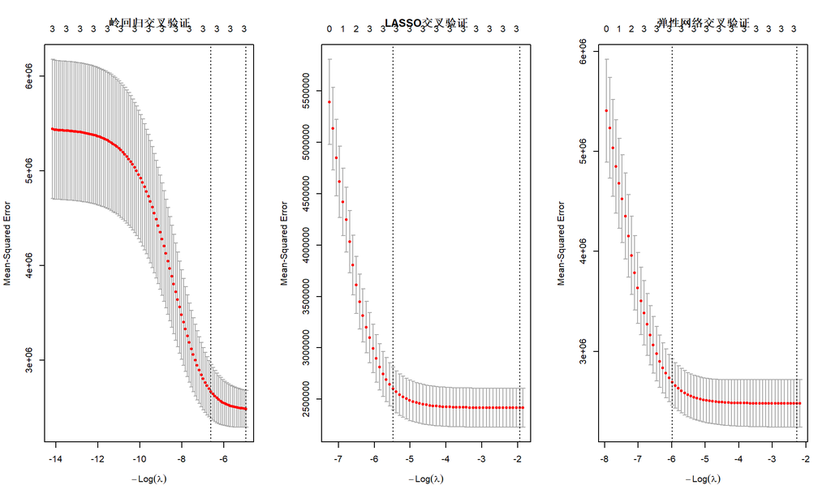

```r
# 可视化交叉验证结果
par(mfrow = c(1, 3))
plot(cv_ridge, main = "岭回归交叉验证")
plot(cv_lasso, main = "LASSO交叉验证")
plot(cv_enet, main = "弹性网络交叉验证")
```

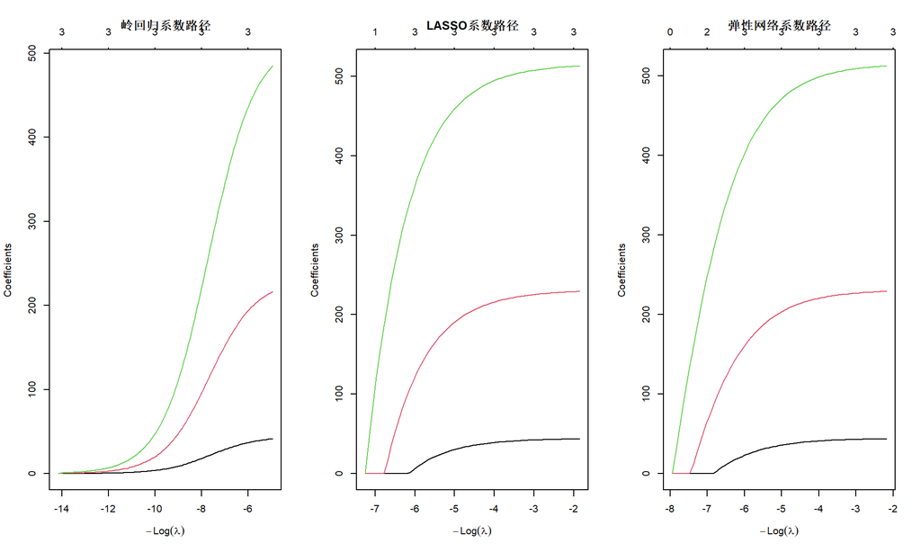

```r
par(mfrow = c(1, 1))

# 可视化系数路径
par(mfrow = c(1, 3))
plot(ridge_model, xvar = "lambda", main = "岭回归系数路径")
plot(lasso_model, xvar = "lambda", main = "LASSO系数路径")
plot(enet_model, xvar = "lambda", main = "弹性网络系数路径")
```

```r
par(mfrow = c(1, 1))
```

## 1.14 分段回归与样条回归

### 意义与使用场景

**核心意义**：分段回归和样条回归用于处理自变量与因变量之间的非线性关系，提供更灵活的建模方式。

**适用场景**： - **概括**：当变量间关系呈现非线性（如阈值效应、拐点）时使用 - **医学举例**：药物剂量-效应关系中存在阈值效应；年龄与疾病风险呈U型关系 - **其他领域**：经济学中的恩格尔曲线；环境科学中污染物浓度与生态效应的关系

**方法选择**：分段回归适合已知断点的情况，样条回归适合未知断点或需要光滑曲线的情况

### 数学基础

**分段回归（Piecewise Regression）**：

在自变量的不同区间使用不同的线性函数拟合。

**模型形式**（以一个断点为例）：
$$Y_i = \beta_0 + \beta_1 X_i + \beta_2 (X_i - c)_+
+ \varepsilon_i$$

其中 $(X_i - c)_+ = \max(0, X_i - c)$，$c$为断点。

**样条回归（Spline Regression）**：

使用分段多项式函数，且在断点处光滑连接。

**B样条（B-spline）**：

使用基函数的线性组合：
$$f(X) =
\sum_{j=1}^{k} \beta_j B_j(X)$$

**参数说明**： - $B_j(X)$：第$j$个B样条基函数 - $k$：基函数个数，由节点数和多项式阶数决定

**自然样条（Natural Spline）**：

在边界处强制线性，减少边界效应。

**光滑样条（Smoothing Spline）**：

$$\hat{f} = \arg\min_f \left\{
\sum_{i=1}^{n}(Y_i - f(X_i))^2 + \lambda \int [f''(x)]^2 dx
\right\}$$

**参数说明**： - $\lambda$：光滑参数，控制拟合程度与光滑程度的平衡 - $\int [f''(x)]^2 dx$：曲率的积分，衡量函数的光滑程度

**有效自由度**：
$$df_{\lambda} =
trace(\mathbf{S}_\lambda)$$

其中$\mathbf{S}_\lambda$为光滑矩阵。

### 代码实现

```r
# 模拟非线性关系数据
set.seed(444)
n_spline <- 150
x_spline <- runif(n_spline, 0, 10)
# 真实函数：分段线性
y_true <- ifelse(x_spline < 5, 10 + 2 * x_spline, 20 + 1 * (x_spline - 5))
y_spline <- y_true + rnorm(n_spline, 0, 2)

data_spline <- data.frame(x = x_spline, y = y_spline)

# 1. 线性回归（基准）
model_linear <- lm(y ~ x, data = data_spline)

# 2. 分段回归（已知断点c=5）
data_spline$x_minus_c <- pmax(data_spline$x - 5, 0)
model_piecewise <- lm(y ~ x + x_minus_c, data = data_spline)
summary(model_piecewise)
```

```
##
## Call:
## lm(formula = y ~ x + x_minus_c, data = data_spline)
##
## Residuals:
##     Min      1Q  Median      3Q     Max
## -5.4531 -1.2837 -0.2629  1.1029  5.9187
##
## Coefficients:
##             Estimate Std. Error t value Pr(>|t|)
## (Intercept)  10.9130     0.4452  24.510  < 2e-16 ***
## x             1.7788     0.1337  13.304  < 2e-16 ***
## x_minus_c    -0.7688     0.2383  -3.226  0.00155 **
## ---
## Signif. codes:  0 '***' 0.001 '**' 0.01 '*' 0.05 '.' 0.1 ' ' 1
##
## Residual standard error: 2.018 on 147 degrees of freedom
## Multiple R-squared:  0.7927, Adjusted R-squared:  0.7898
## F-statistic:   281 on 2 and 147 DF,  p-value: < 2.2e-16
```

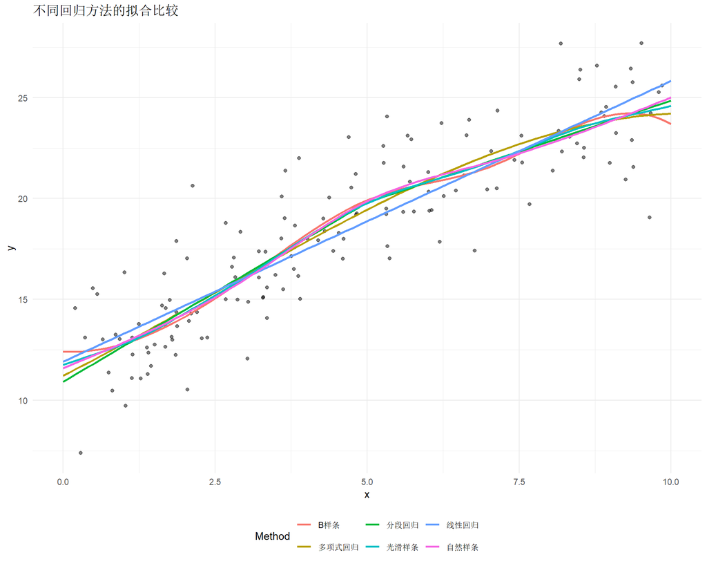

```r
# 3. 多项式回归
model_poly <- lm(y ~ poly(x, degree = 3), data = data_spline)

# 4. B样条回归
model_bspline <- lm(y ~ splines::bs(x, knots = c(3, 5, 7)), data = data_spline)

# 5. 自然样条回归
model_nspline <- lm(y ~ splines::ns(x, knots = c(3, 5, 7)), data = data_spline)

# 6. 光滑样条回归
smooth_spline <- smooth.spline(data_spline$x, data_spline$y, df = 6)

# 预测新数据
new_x <- seq(0, 10, length.out = 100)
new_data <- data.frame(x = new_x, x_minus_c = pmax(new_x - 5, 0))

pred_linear <- predict(model_linear, newdata = new_data)
pred_piecewise <- predict(model_piecewise, newdata = new_data)
pred_poly <- predict(model_poly, newdata = new_data)
pred_bspline <- predict(model_bspline, newdata = new_data)
pred_nspline <- predict(model_nspline, newdata = new_data)
pred_smooth <- predict(smooth_spline, new_x)$y

# 可视化比较
plot_df <- data.frame(
  x = rep(new_x, 6),
  y = c(pred_linear, pred_piecewise, pred_poly, pred_bspline, pred_nspline, pred_smooth),
  Method = rep(c("线性回归", "分段回归", "多项式回归", "B样条", "自然样条", "光滑样条"), each = 100)
)

ggplot2::ggplot() +
  ggplot2::geom_point(data = data_spline, ggplot2::aes(x = x, y = y), alpha = 0.5) +
  ggplot2::geom_line(data = plot_df, ggplot2::aes(x = x, y = y, color = Method), linewidth = 1) +
  ggplot2::labs(title = "不同回归方法的拟合比较", x = "x", y = "y") +
  ggplot2::theme_minimal() +
  ggplot2::theme(legend.position = "bottom")
```

```r
# 模型比较
cat("========== 模型比较 ==========\n")
```

```
## ========== 模型比较 ==========
```

```r
cat(sprintf("线性回归: R² = %.4f, AIC = %.2f\n",
            summary(model_linear)$r.squared, AIC(model_linear)))
```

```
## 线性回归: R² = 0.7780, AIC = 649.50
```

```r
cat(sprintf("分段回归: R² = %.4f, AIC = %.2f\n",
            summary(model_piecewise)$r.squared, AIC(model_piecewise)))
```

```
## 分段回归: R² = 0.7927, AIC = 641.24
```

```r
cat(sprintf("多项式回归: R² = %.4f, AIC = %.2f\n",
            summary(model_poly)$r.squared, AIC(model_poly)))
```

```
## 多项式回归: R² = 0.7912, AIC = 644.30
```

```r
cat(sprintf("B样条: R² = %.4f, AIC = %.2f\n",
            summary(model_bspline)$r.squared, AIC(model_bspline)))
```

```
## B样条: R² = 0.7965, AIC = 646.46
```

```r
cat(sprintf("自然样条: R² = %.4f, AIC = %.2f\n",
            summary(model_nspline)$r.squared, AIC(model_nspline)))
```

```
## 自然样条: R² = 0.7938, AIC = 644.44
```

## 第一章小结

### 核心知识点总结

| 主题 | 核心内容 | 关键函数 |
| --- | --- | --- |
| OLS估计 | 最小化残差平方和 | `lm()` |
| 系数解释 | 控制其他变量时的边际效应 | `coef()`, `tidy()` |
| R² | 模型解释变异的比例 | `summary()$r.squared` |
| ANOVA | 变异分解与整体检验 | `anova()` |
| 残差诊断 | 正态性、异方差性检验 | `plot()`, `bptest()` |
| 影响点诊断 | Cook距离、杠杆值 | `cooks.distance()`, `hatvalues()` |
| 多重共线性 | VIF、条件数 | `car::vif()` |
| 变量选择 | 逐步回归、最佳子集 | `step()`, `regsubsets()` |
| 稳健标准误 | HC0-HC3、聚类稳健 | `sandwich::vcovHC()` |
| 正则化 | 岭回归、LASSO | `glmnet::glmnet()` |
| 样条回归 | B样条、自然样条 | `splines::bs()`, `splines::ns()` |

# 第二章：广义线性模型

广义线性模型（Generalized Linear Models, GLM）是线性回归的重要扩展，可以处理非正态分布的因变量，如二分类数据、计数数据等。本章将系统讲解GLM的理论框架及其在医学研究中的应用。

## 2.1 指数族分布

### 意义与使用场景

**核心意义**：指数族分布是广义线性模型的理论基础，统一了多种常见分布的数学框架，使得不同类型的因变量可以用统一的方法建模。

**举例**：研究患者是否患糖尿病（是/否）与年龄、BMI、家族史的关系

**为什么这种数据适合用广义线性模型？**

因变量”是否患糖尿病”是二分类变量（0=否，1=是），取值只能是0或1，不符合正态分布的连续性假设。如果强行用普通线性回归，预测值可能超出[0,1]区间，且残差不满足正态性和同方差性。此时应选择二项分布作为因变量的分布类型，配合logit链接函数，构建逻辑回归模型。这种”二分类因变量+二项分布假设+logit链接”的组合，正是广义线性模型处理二分类数据的标准方案。

**研究目的是什么？**

1. 估计患病风险：计算给定特征下患糖尿病的概率。
2. 识别危险因素：判断哪些因素显著影响患病风险。
3. 风险预测：建立预测模型，筛查高危人群。

**可能得到什么样的结果？**

假设逻辑回归结果为：logit(P) = -5 + 0.05×年龄 + 0.1×BMI + 1.2×家族史

**需要注意什么？**

二分类数据需要足够的样本量和事件数（通常每组至少10个事件）。如果存在过度离散（方差大于理论值），需要使用准似然或负二项模型。此外，逻辑回归的系数解释是odds ratio而非risk ratio，两者在概率较高时有差异。

### 数学基础

**指数族分布**：

广义线性模型要求因变量的分布属于指数族，其概率密度函数可表示为：

$$f(y; \theta, \phi) = \exp\left\{
\frac{y\theta - b(\theta)}{a(\phi)} + c(y, \phi) \right\}$$

**参数说明**： - $\theta$：自然参数（canonical parameter） - $\phi$：离散参数（dispersion parameter） - $b(\theta)$：累积函数 - $a(\phi)$：尺度函数 - $c(y, \phi)$：归一化常数

**常见指数族分布**：

| 分布 | $\theta$ | $b(\theta)$ | $a(\phi)$ | 均值 $E(Y)$ | 方差 $Var(Y)$ |
| --- | --- | --- | --- | --- | --- |
| 正态 | $\mu$ | $\theta^2/2$ | $\sigma^2$ | $\mu$ | $\sigma^2$ |
| 二项 | $\log(p/(1-p))$ | $\log(1+e^\theta)$ | 1 | $np$ | $np(1-p)$ |
| 泊松 | $\log(\lambda)$ | $e^\theta$ | 1 | $\lambda$ | $\lambda$ |
| Gamma | $-1/\mu$ | $-\log(-\theta)$ | $1/\nu$ | $\mu$ | $\mu^2/\nu$ |

**均值与方差的关系**：

$$E(Y) = \mu = b'(\theta)$$
$$Var(Y) = b''(\theta) \cdot a(\phi)
= V(\mu) \cdot a(\phi)$$

其中$V(\mu)$称为方差函数。

### 代码实现

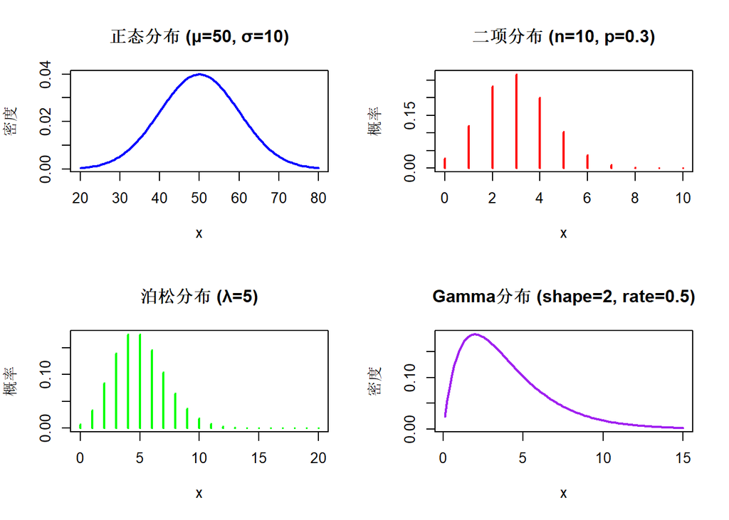

```r
# 演示指数族分布的性质

# 1. 正态分布
mu_normal <- 50
sigma <- 10
x_normal <- seq(20, 80, length.out = 100)
y_normal <- dnorm(x_normal, mean = mu_normal, sd = sigma)

# 2. 二项分布（n=10, p=0.3）
n_binom <- 10
p_binom <- 0.3
x_binom <- 0:n_binom
y_binom <- dbinom(x_binom, size = n_binom, prob = p_binom)

# 3. 泊松分布（lambda=5）
lambda_pois <- 5
x_pois <- 0:20
y_pois <- dpois(x_pois, lambda = lambda_pois)

# 4. Gamma分布（shape=2, rate=0.5）
shape_gamma <- 2
rate_gamma <- 0.5
x_gamma <- seq(0.1, 15, length.out = 100)
y_gamma <- dgamma(x_gamma, shape = shape_gamma, rate = rate_gamma)

# 可视化
par(mfrow = c(2, 2))
plot(x_normal, y_normal, type = "l", main = "正态分布 (μ=50, σ=10)",
     xlab = "x", ylab = "密度", col = "blue", lwd = 2)
plot(x_binom, y_binom, type = "h", main = "二项分布 (n=10, p=0.3)",
     xlab = "x", ylab = "概率", col = "red", lwd = 2)
plot(x_pois, y_pois, type = "h", main = "泊松分布 (λ=5)",
     xlab = "x", ylab = "概率", col = "green", lwd = 2)
plot(x_gamma, y_gamma, type = "l", main = "Gamma分布 (shape=2, rate=0.5)",
     xlab = "x", ylab = "密度", col = "purple", lwd = 2)
```

```r
par(mfrow = c(1, 1))

# 验证均值-方差关系
cat("========== 均值-方差关系验证 ==========\n")
```

```
## ========== 均值-方差关系验证 ==========
```

```r
cat(sprintf("正态分布: 均值=%.1f, 方差=%.1f\n", mu_normal, sigma^2))
```

```
## 正态分布: 均值=50.0, 方差=100.0
```

```r
cat(sprintf("二项分布: 均值=%.1f, 方差=%.1f (理论: np(1-p)=%.1f)\n",
            n_binom * p_binom, n_binom * p_binom * (1 - p_binom),
            n_binom * p_binom * (1 - p_binom)))
```

```
## 二项分布: 均值=3.0, 方差=2.1 (理论: np(1-p)=2.1)
```

```r
cat(sprintf("泊松分布: 均值=%.1f, 方差=%.1f (理论: λ=%.1f)\n",
            lambda_pois, lambda_pois, lambda_pois))
```

```
## 泊松分布: 均值=5.0, 方差=5.0 (理论: λ=5.0)
```

```r
cat(sprintf("Gamma分布: 均值=%.1f, 方差=%.1f\n",
            shape_gamma/rate_gamma, shape_gamma/rate_gamma^2))
```

```
## Gamma分布: 均值=4.0, 方差=8.0
```

## 2.2 链接函数

### 意义与使用场景

**核心意义**：链接函数是广义线性模型的核心组件，它将因变量的均值与线性预测器连接起来，使得非线性关系可以用线性模型框架处理。

**举例**：比较logit和probit链接函数在疾病风险预测中的选择

**为什么需要链接函数？**

在疾病风险预测中，因变量是患病概率P，取值范围是[0,1]，而线性预测器η = β₀ + β₁X₁ + … 的取值范围是(-∞, +∞)。两者无法直接等价，需要一个”桥梁”函数将概率映射到整个实数轴。logit函数g(P) = log(P/(1-P))将[0,1]映射到(-∞, +∞)，probit函数g(P) = Φ⁻¹(P)利用标准正态分布的逆函数实现同样的映射。选择不同的链接函数，相当于对概率做不同的变换后再建模。

**研究目的是什么？**

1. 选择最佳链接函数：比较logit、probit、cloglog等链接函数的拟合效果。
2. 确保预测合理性：保证预测概率始终在[0,1]区间内。
3. 便于结果解释：logit链接的结果可直接解释为优势比（OR）。

**可能得到什么样的结果？**

对于同一数据集，不同链接函数的拟合结果：

1. 系数差异：logit和probit的系数数值不同（probit系数通常约为logit的0.6倍），但统计显著性一致。
2. 预测概率：三种链接函数预测的概率在中间区域接近，在极端概率区域有差异。
3. 选择建议：如果需要解释为OR，选logit；如果假设潜在变量服从正态分布，选probit；如果事件发生概率很低，考虑cloglog。

**需要注意什么？**

logit和probit在大多数情况下结果相似，选择主要基于解释便利性。cloglog是非对称链接函数，适用于稀有事件。链接函数选择不当可能导致预测概率超出合理范围或拟合效果不佳。

### 数学基础

**链接函数（Link Function）**：

连接均值$\mu$与线性预测器$\eta = \mathbf{X}\boldsymbol{\beta}$的函数。

$$g(\mu) = \eta =
\mathbf{X}\boldsymbol{\beta}$$

**常见链接函数**：

| 分布 | 典型链接函数 | $g(\mu)$ | $g^{-1}(\eta)$ |
| --- | --- | --- | --- |
| 正态 | identity | $\mu$ | $\eta$ |
| 二项 | logit | $\log(\mu/(1-\mu))$ | $e^\eta/(1+e^\eta)$ |
| 二项 | probit | $\Phi^{-1}(\mu)$ | $\Phi(\eta)$ |
| 二项 | cloglog | $\log(-\log(1-\mu))$ | $1-\exp(-e^\eta)$ |
| 泊松 | log | $\log(\mu)$ | $e^\eta$ |
| Gamma | inverse | $1/\mu$ | $1/\eta$ |

**典型链接函数（Canonical Link）**：

当$g(\mu) = \theta$时，即链接函数等于自然参数，称为典型链接函数。使用典型链接函数可以简化估计过程。

**链接函数的选择原则**：

1. **理论依据**：根据因变量的分布特性选择
2. **解释便利**：logit链接便于解释为优势比
3. **拟合效果**：比较不同链接函数的拟合优度

### 代码实现

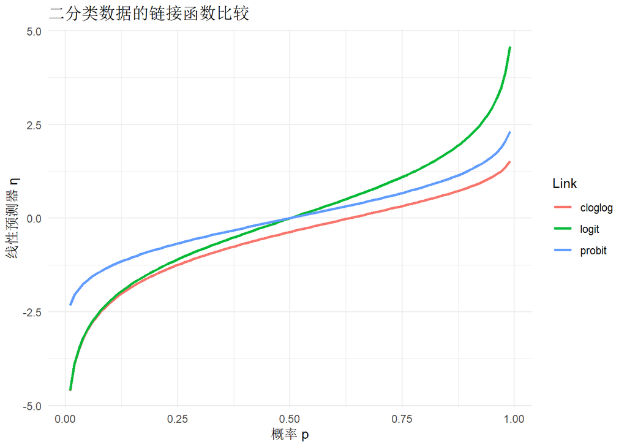

```r
# 演示不同链接函数的性质

# 定义链接函数
logit_link <- function(p) log(p / (1 - p))
logit_inv <- function(eta) exp(eta) / (1 + exp(eta))

probit_link <- function(p) qnorm(p)
probit_inv <- function(eta) pnorm(eta)

cloglog_link <- function(p) log(-log(1 - p))
cloglog_inv <- function(eta) 1 - exp(-exp(eta))

log_link <- function(mu) log(mu)
log_inv <- function(eta) exp(eta)

# 可视化二分类数据的链接函数
p_seq <- seq(0.01, 0.99, length.out = 100)

plot_df <- data.frame(
  p = rep(p_seq, 3),
  eta = c(logit_link(p_seq), probit_link(p_seq), cloglog_link(p_seq)),
  Link = rep(c("logit", "probit", "cloglog"), each = 100)
)

ggplot2::ggplot(plot_df, ggplot2::aes(x = p, y = eta, color = Link)) +
  ggplot2::geom_line(linewidth = 1) +
  ggplot2::labs(title = "二分类数据的链接函数比较",
                x = "概率 p", y = "线性预测器 η") +
  ggplot2::theme_minimal()
```

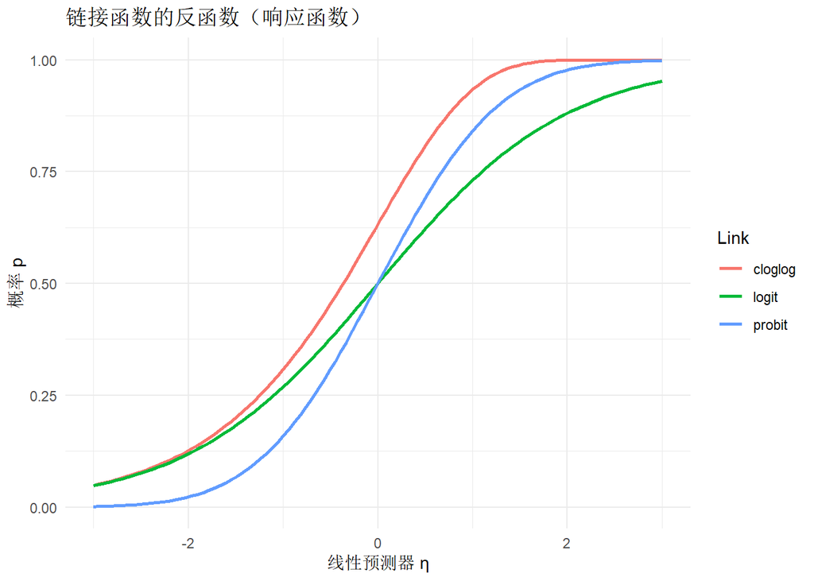

```r
# 比较反函数（从η到p）
eta_seq <- seq(-3, 3, length.out = 100)

inv_df <- data.frame(
  eta = rep(eta_seq, 3),
  p = c(logit_inv(eta_seq), probit_inv(eta_seq), cloglog_inv(eta_seq)),
  Link = rep(c("logit", "probit", "cloglog"), each = 100)
)

ggplot2::ggplot(inv_df, ggplot2::aes(x = eta, y = p, color = Link)) +
  ggplot2::geom_line(linewidth = 1) +
  ggplot2::labs(title = "链接函数的反函数（响应函数）",
                x = "线性预测器 η", y = "概率 p") +
  ggplot2::theme_minimal()
```

## 2.3 逻辑回归（二分类）

### 意义与使用场景

**核心意义**：逻辑回归是处理二分类因变量的标准方法，通过logit变换将概率映射到实数域，便于建模和解释。

**举例**：研究年龄、BMI、家族史对糖尿病发病的影响

**为什么这种数据适合用逻辑回归？**

首先，因变量”是否患糖尿病”是典型的二分类变量（患病=1，未患病=0），取值只有两种可能。其次，我们需要研究的是”患病概率”与自变量的关系，而不是患病与否的简单预测。逻辑回归通过logit变换将概率（0到1之间）映射到实数域（负无穷到正无穷），使得可以用线性模型建模。这种”二分类因变量+概率建模需求”的场景，正是逻辑回归的典型应用。

**研究目的是什么？**

本研究有三个层次的目的：1. 识别危险因素：判断哪些因素与糖尿病发病显著相关；2. 量化风险程度：计算优势比（OR），回答”年龄每增加10岁，糖尿病风险增加多少倍”；3. 预测应用：建立风险预测模型，识别高危人群进行早期干预。

**可能得到什么样的结果？**

假设回归结果为：logit(p) = -5.2 + 0.05×年龄 + 0.12×BMI + 1.3×家族史

**需要注意什么？**

逻辑回归假设自变量与logit(p)呈线性关系，实际中可能存在非线性关系（如年龄与患病风险可能呈U型）。此外，样本量要求：每个自变量至少需要10个阳性事件。当事件发生率很低时（如罕见病），需要考虑稀疏数据问题。

### 数学基础

**逻辑回归模型**：

用于二分类因变量的回归模型，使用logit链接函数。

**模型形式**：
$$\log\left(\frac{p}{1-p}\right) = \beta_0 +
\beta_1 X_1 + \cdots + \beta_p X_p$$

等价于：
$$p = \frac{\exp(\beta_0 +
\beta_1 X_1 + \cdots + \beta_p X_p)}{1 + \exp(\beta_0 + \beta_1 X_1 +
\cdots + \beta_p X_p)}$$

**参数估计**：

使用极大似然估计（Maximum Likelihood Estimation, MLE）。

**似然函数**：
$$L(\boldsymbol{\beta}) = \prod_{i=1}^{n} p_i^{y_i}
(1-p_i)^{1-y_i}$$

**对数似然函数**：
$$\ell(\boldsymbol{\beta}) = \sum_{i=1}^{n} \left[
y_i \log(p_i) + (1-y_i)\log(1-p_i) \right]$$

**优势比（Odds Ratio, OR）**：

$$OR = \frac{p_1/(1-p_1)}{p_0/(1-p_0)} =
e^{\beta}$$

**参数说明**： - $p$：事件发生的概率 - $p/(1-p)$：优势（odds） - $OR$：暴露组与对照组优势之比

**OR的解释**： - $OR = 1$：无关联 - $OR > 1$：正向关联（风险因素） - $OR < 1$：负向关联（保护因素）

### 代码实现

```r
# 模拟疾病诊断数据
# 场景：研究年龄、BMI、家族史对糖尿病发病的影响

set.seed(456)
n_glm <- 300

# 生成自变量
age_glm <- round(rnorm(n_glm, mean = 50, sd = 12))
bmi_glm <- round(rnorm(n_glm, mean = 26, sd = 4), 1)
family_history <- rbinom(n_glm, 1, 0.3)  # 家族史（0=无，1=有）

# 生成因变量：糖尿病（0=无，1=有）
# 真实模型：logit(p) = -5 + 0.05*年龄 + 0.1*BMI + 1.2*家族史
linear_pred <- -5 + 0.05 * age_glm + 0.1 * bmi_glm + 1.2 * family_history
prob_diabetes <- exp(linear_pred) / (1 + exp(linear_pred))
diabetes <- rbinom(n_glm, 1, prob_diabetes)

# 创建数据框
diabetes_data <- data.frame(
  patient_id = 1:n_glm,
  age = age_glm,
  bmi = bmi_glm,
  family_history = factor(family_history, levels = c(0, 1), labels = c("无", "有")),
  diabetes = factor(diabetes, levels = c(0, 1), labels = c("无", "有"))
)

# 查看数据结构
str(diabetes_data)
```

```
## 'data.frame':    300 obs. of  5 variables:
##  $ patient_id    : int  1 2 3 4 5 6 7 8 9 10 ...
##  $ age           : num  34 57 60 33 41 46 58 53 62 57 ...
##  $ bmi           : num  21.5 27.6 23.3 34.5 24.9 27 21.7 20.7 31.2 25.3 ...
##  $ family_history: Factor w/ 2 levels "无","有": 1 1 1 1 1 2 1 1 2 1 ...
##  $ diabetes      : Factor w/ 2 levels "无","有": 1 1 1 2 1 2 1 2 2 2 ...
```

```r
# 描述性统计
table(diabetes_data$diabetes)
```

```
##
##  无  有
## 107 193
```

```r
prop.table(table(diabetes_data$diabetes))
```

```
##
##        无        有
## 0.3566667 0.6433333
```

```r
# 拟合逻辑回归模型
model_logit <- glm(diabetes ~ age + bmi + family_history,
                   data = diabetes_data,
                   family = binomial(link = "logit"))

# 查看模型摘要
summary(model_logit)
```

```
##
## Call:
## glm(formula = diabetes ~ age + bmi + family_history, family = binomial(link = "logit"),
##     data = diabetes_data)
##
## Coefficients:
##                  Estimate Std. Error z value Pr(>|z|)
## (Intercept)      -5.87119    1.19649  -4.907 9.25e-07 ***
## age               0.04896    0.01175   4.166 3.10e-05 ***
## bmi               0.14412    0.03570   4.037 5.42e-05 ***
## family_history有  0.92870    0.30945   3.001  0.00269 **
## ---
## Signif. codes:  0 '***' 0.001 '**' 0.01 '*' 0.05 '.' 0.1 ' ' 1
##
## (Dispersion parameter for binomial family taken to be 1)
##
##     Null deviance: 390.89  on 299  degrees of freedom
## Residual deviance: 349.43  on 296  degrees of freedom
## AIC: 357.43
##
## Number of Fisher Scoring iterations: 3
```

```r
# 提取系数和优势比
coef_logit <- broom::tidy(model_logit, conf.int = TRUE, exponentiate = TRUE)
cat("\n========== 优势比（OR）及95%%置信区间 ==========\n")
```

```
##
## ========== 优势比（OR）及95%%置信区间 ==========
```

```r
print(coef_logit)
```

```
## # A tibble: 4 × 7
##   term             estimate std.error statistic     p.value conf.low conf.high
##   <chr>               <dbl>     <dbl>     <dbl>       <dbl>    <dbl>     <dbl>
## 1 (Intercept)       0.00282    1.20       -4.91 0.000000925 0.000249    0.0274
## 2 age               1.05       0.0118      4.17 0.0000310   1.03        1.08
## 3 bmi               1.16       0.0357      4.04 0.0000542   1.08        1.24
## 4 family_history有  2.53       0.309       3.00 0.00269     1.40        4.74
```

```r
# 解释优势比
cat("\n========== 优势比解释 ==========\n")
```

```
##
## ========== 优势比解释 ==========
```

```r
cat(sprintf("年龄: OR = %.3f，年龄每增加1岁，糖尿病风险增加%.1f%%\n",
            coef_logit$estimate[2], (coef_logit$estimate[2] - 1) * 100))
```

```
## 年龄: OR = 1.050，年龄每增加1岁，糖尿病风险增加5.0%
```

```r
cat(sprintf("BMI: OR = %.3f，BMI每增加1，糖尿病风险增加%.1f%%\n",
            coef_logit$estimate[3], (coef_logit$estimate[3] - 1) * 100))
```

```
## BMI: OR = 1.155，BMI每增加1，糖尿病风险增加15.5%
```

```r
cat(sprintf("家族史: OR = %.3f，有家族史者糖尿病风险是无家族史者的%.2f倍\n",
            coef_logit$estimate[4], coef_logit$estimate[4]))
```

```
## 家族史: OR = 2.531，有家族史者糖尿病风险是无家族史者的2.53倍
```

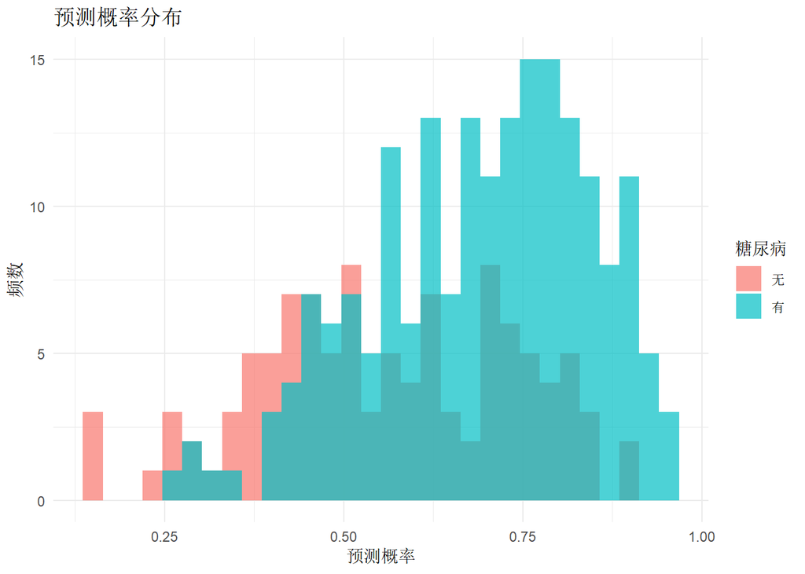

```r
# 预测概率
diabetes_data$pred_prob <- predict(model_logit, type = "response")

# 绘制预测概率分布
ggplot2::ggplot(diabetes_data, ggplot2::aes(x = pred_prob, fill = diabetes)) +
  ggplot2::geom_histogram(bins = 30, alpha = 0.7, position = "identity") +
  ggplot2::labs(title = "预测概率分布", x = "预测概率", y = "频数", fill = "糖尿病") +
  ggplot2::theme_minimal()
```

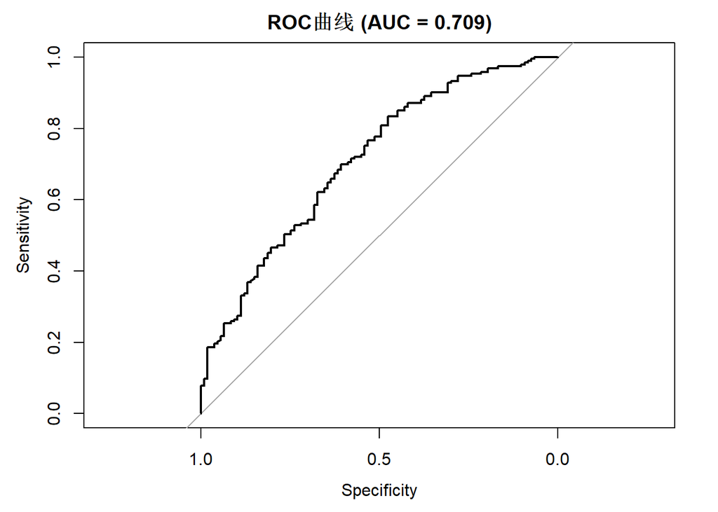

```r
# ROC曲线
library(pROC)
roc_curve <- pROC::roc(diabetes_data$diabetes, diabetes_data$pred_prob, quiet = TRUE)
plot(roc_curve, main = sprintf("ROC曲线 (AUC = %.3f)", pROC::auc(roc_curve)))
```

## 2.4 多项逻辑回归

### 意义与使用场景

**核心意义**：多项逻辑回归用于处理多分类无序因变量，是二分类逻辑回归的自然扩展。

**举例**：研究年龄、BMI对疾病分型（I型、II型、III型）的影响

**为什么这种数据适合用多项逻辑回归？**

首先，因变量”疾病分型”有三个类别（I型、II型、III型），且类别之间没有等级关系（I型不一定比II型轻或重）。其次，二分类逻辑回归无法处理三个及以上类别的问题，需要扩展方法。多项逻辑回归通过设定参照类别，将多分类问题转化为多个二分类比较：I型vs III型、II型vs III型，从而实现对多分类因变量的建模。

**研究目的是什么？**

本研究有三个层次的目的：1. 识别分型相关因素：判断哪些因素与疾病分型相关；2. 量化相对风险：计算相对风险比（RRR），回答”年龄每增加10岁，患II型而非III型的相对风险是多少”；3. 预测应用：根据患者特征预测最可能的疾病分型，指导个体化治疗。

**可能得到什么样的结果？**

假设回归结果（以III型为参照）：I型vs III型的年龄RRR=0.85，II型vs III型的年龄RRR=0.92。

1. 年龄效应解读：年龄每增加1岁，患I型而非III型的相对风险降低15%；患II型而非III型的相对风险降低8%。
2. 分型趋势：年龄越大，越倾向于患III型（最严重）疾病。
3. 预测应用：一位70岁、BMI=30的患者，预测为III型的概率最高（约55%）。
4. 临床意义：年轻患者更可能患I型疾病，治疗方案应有所区别。

**需要注意什么？**

参照类别的选择会影响结果解释，应选择临床意义明确或样本量较大的类别作为参照。当类别数较多时，模型参数会急剧增加，需要足够的样本量。如果类别之间存在顺序关系（如轻、中、重），应考虑使用序数逻辑回归以提高效率。

### 数学基础

**多项逻辑回归（Multinomial Logistic Regression）**：

用于因变量有多个无序分类的情况。

**模型形式**：

以第$J$类为参照组：
$$\log\left(\frac{P(Y=k)}{P(Y=J)}\right) =
\beta_{k0} + \beta_{k1} X_1 + \cdots + \beta_{kp} X_p$$

**概率计算**：
$$P(Y=k) =
\frac{\exp(\beta_{k0} + \beta_{k1} X_1 + \cdots)}{\sum_{j=1}^{J}
\exp(\beta_{j0} + \beta_{j1} X_1 + \cdots)}$$

**相对风险比（RRR）**：
$$RRR_k = e^{\beta_k} =
\frac{P(Y=k|X)/P(Y=J|X)}{P(Y=k|X')/P(Y=J|X')}$$

### 代码实现

```r
# 模拟疾病严重程度数据（轻、中、重）
set.seed(567)
n_multi <- 200

# 生成自变量
age_multi <- round(rnorm(n_multi, mean = 55, sd = 10))
bmi_multi <- round(rnorm(n_multi, mean = 27, sd = 4), 1)

# 生成因变量：疾病严重程度
# 真实模型参数
beta_mild <- c(-2, 0.02, 0.05)      # 轻度 vs 重度
beta_moderate <- c(-1, 0.03, 0.08)  # 中度 vs 重度

linear_mild <- beta_mild[1] + beta_mild[2] * age_multi + beta_mild[3] * bmi_multi
linear_moderate <- beta_moderate[1] + beta_moderate[2] * age_multi + beta_moderate[3] * bmi_multi

# 计算概率（以重度为参照）
p_mild <- exp(linear_mild) / (1 + exp(linear_mild) + exp(linear_moderate))
p_moderate <- exp(linear_moderate) / (1 + exp(linear_mild) + exp(linear_moderate))
p_severe <- 1 - p_mild - p_moderate

# 生成分类结果
prob_matrix <- cbind(p_mild, p_moderate, p_severe)
severity <- apply(prob_matrix, 1, function(p) sample(1:3, 1, prob = p))

# 创建数据框
severity_data <- data.frame(
  age = age_multi,
  bmi = bmi_multi,
  severity = factor(severity, levels = 1:3, labels = c("轻度", "中度", "重度"))
)

# 查看分布
table(severity_data$severity)
```

```
##
## 轻度 中度 重度
##   23  163   14
```

```r
# 使用nnet包进行多项逻辑回归
library(nnet)
model_multi <- nnet::multinom(severity ~ age + bmi, data = severity_data, trace = FALSE)

# 查看结果
summary(model_multi)
```

```
## Call:
## nnet::multinom(formula = severity ~ age + bmi, data = severity_data,
##     trace = FALSE)
##
## Coefficients:
##      (Intercept)          age         bmi
## 中度    2.255785  0.005712371 -0.02230257
## 重度    3.443118 -0.037602609 -0.07479578
##
## Std. Errors:
##      (Intercept)        age        bmi
## 中度    1.932305 0.02159939 0.05815893
## 重度    2.825002 0.03217397 0.08783445
##
## Residual Deviance: 237.0525
## AIC: 249.0525
```

```r
# 提取系数
coef_multi <- coef(model_multi)
cat("\n========== 多项逻辑回归系数 ==========\n")
```

```
##
## ========== 多项逻辑回归系数 ==========
```

```r
print(coef_multi)
```

```
##      (Intercept)          age         bmi
## 中度    2.255785  0.005712371 -0.02230257
## 重度    3.443118 -0.037602609 -0.07479578
```

```r
# 计算相对风险比
rrr <- exp(coef_multi)
cat("\n========== 相对风险比（RRR） ==========\n")
```

```
##
## ========== 相对风险比（RRR） ==========
```

```r
print(rrr)
```

```
##      (Intercept)       age       bmi
## 中度    9.542784 1.0057287 0.9779443
## 重度   31.284338 0.9630956 0.9279330
```

```r
# 预测
severity_data$pred_class <- predict(model_multi)
severity_data$pred_prob <- predict(model_multi, type = "probs")

# 混淆矩阵
cat("\n========== 混淆矩阵 ==========\n")
```

```
##
## ========== 混淆矩阵 ==========
```

```r
print(table(实际 = severity_data$severity, 预测 = severity_data$pred_class))
```

```
##       预测
## 实际 轻度 中度 重度
##   轻度    0   23    0
##   中度    0  163    0
##   重度    0   14    0
```

```r
# 计算准确率
accuracy <- mean(severity_data$severity == severity_data$pred_class)
cat(sprintf("\n预测准确率: %.2f%%\n", accuracy * 100))
```

```
##
## 预测准确率: 81.50%
```

## 2.5 序数逻辑回归

### 意义与使用场景

**核心意义**：序数逻辑回归用于处理有序分类因变量，利用类别间的顺序信息提高估计效率。

**举例**：研究年龄、BMI对疾病严重程度（轻度、中度、重度）的影响

**为什么这种数据适合用序数逻辑回归？**

首先，因变量”疾病严重程度”有三个类别（轻度、中度、重度），且类别之间存在明确的顺序关系：轻度<中度<重度。其次，多项逻辑回归忽略了类别间的顺序信息，会损失估计效率。序数逻辑回归通过累积logit模型，假设自变量对不同切分点（轻度vs中重度、轻中度vs重度）的影响相同，从而减少参数数量，提高估计效率。

**研究目的是什么？**

本研究有三个层次的目的：1. 识别严重程度相关因素：判断哪些因素与疾病严重程度相关；2. 量化累积效应：计算优势比，回答”年龄每增加10岁，疾病处于更严重等级的优势是多少”；3. 验证比例优势假设：检验自变量对不同切分点的影响是否一致。

**可能得到什么样的结果？**

假设回归结果为：年龄OR=1.08，BMI OR=1.15，比例优势假设检验p值=0.35。

1. 年龄效应：年龄每增加1岁，疾病处于更严重等级的优势增加8%；增加10岁优势增加116%。
2. BMI效应：BMI每增加1个单位，疾病处于更严重等级的优势增加15%。
3. 比例优势假设：p值>0.05，假设成立，年龄和BMI对轻度vs中重度、轻中度vs重度的影响一致。
4. 预测应用：一位70岁、BMI=30的患者，预测为重度的概率最高（约60%）。

**需要注意什么？**

序数逻辑回归的核心假设是比例优势假设，即自变量对不同切分点的影响相同。当假设不成立时（p值<0.05），需要考虑使用偏比例优势模型或退回到多项逻辑回归。此外，序数逻辑回归的系数解释是”累积”效应，而非针对某一特定类别的效应。

### 数学基础

**序数逻辑回归（Ordinal Logistic Regression）**：

用于因变量有有序分类的情况，常用累积logit模型。

**累积logit模型**：
$$\log\left(\frac{P(Y \leq j)}{P(Y > j)}\right)
= \alpha_j - (\beta_1 X_1 + \cdots + \beta_p X_p)$$

**比例优势假设（Proportional Odds Assumption）**：

自变量对不同切分点的影响相同，即$\beta$在各累积logit中保持不变。

**概率计算**：
$$P(Y \leq j)
= \frac{1}{1 + \exp(-(\alpha_j -
\mathbf{X}\boldsymbol{\beta}))}$$
$$P(Y = j) = P(Y \leq j) - P(Y \leq
j-1)$$

### 代码实现

```r
# 使用MASS包的polr函数进行序数逻辑回归
library(MASS)

# 使用之前的严重程度数据
model_ordinal <- MASS::polr(severity ~ age + bmi, data = severity_data, method = "logistic")

# 查看结果
summary(model_ordinal)
```

```
## Call:
## MASS::polr(formula = severity ~ age + bmi, data = severity_data,
##     method = "logistic")
##
## Coefficients:
##        Value Std. Error t value
## age -0.01543    0.01756 -0.8791
## bmi -0.03761    0.04738 -0.7940
##
## Intercepts:
##           Value   Std. Error t value
## 轻度|中度 -3.9107  1.5903    -2.4590
## 中度|重度  0.7571  1.5415     0.4912
##
## Residual Deviance: 239.1523
## AIC: 247.1523
```

```r
# 提取系数
coef_ordinal <- coef(model_ordinal)
cat("\n========== 序数逻辑回归系数 ==========\n")
```

```
##
## ========== 序数逻辑回归系数 ==========
```

```r
print(coef_ordinal)
```

```
##         age         bmi
## -0.01543382 -0.03761387
```

```r
# 计算优势比
or_ordinal <- exp(coef_ordinal)
cat("\n========== 优势比（OR） ==========\n")
```

```
##
## ========== 优势比（OR） ==========
```

```r
print(or_ordinal)
```

```
##       age       bmi
## 0.9846847 0.9630847
```

```r
# 预测
severity_data$pred_ordinal <- predict(model_ordinal)

# 混淆矩阵
cat("\n========== 混淆矩阵 ==========\n")
```

```
##
## ========== 混淆矩阵 ==========
```

```r
print(table(实际 = severity_data$severity, 预测 = severity_data$pred_ordinal))
```

```
##       预测
## 实际 轻度 中度 重度
##   轻度    0   23    0
##   中度    0  163    0
##   重度    0   14    0
```

```r
# 比例优势假设检验
library(brant)
brant_test <- brant::brant(model_ordinal)
```

```
## --------------------------------------------
## Test for X2  df  probability
## --------------------------------------------
## Omnibus      2.12    2   0.35
## age      1.97    1   0.16
## bmi      0.11    1   0.74
## --------------------------------------------
##
## H0: Parallel Regression Assumption holds
```

```r
print(brant_test)
```

```
##                X2 df probability
## Omnibus 2.1176179  2   0.3468687
## age     1.9653524  1   0.1609420
## bmi     0.1094645  1   0.7407546
```

## 2.6 泊松回归

### 意义与使用场景

**核心意义**：泊松回归用于处理计数数据，假设因变量服从泊松分布，均值等于方差。

**举例**：研究年龄、慢性病对年门诊就诊次数的影响

**为什么这种数据适合用泊松回归？**

首先，因变量”年门诊就诊次数”是典型的计数数据，取值为非负整数（0, 1, 2, …）。其次，泊松分布假设计数变量的均值等于方差，当这一假设满足时，泊松回归是最有效的建模方法。门诊就诊次数在一般人群中通常满足这一条件：年均就诊次数约5次，方差也约为5。这种”计数因变量+均值≈方差”的数据结构，正是泊松回归的典型适用场景。

**研究目的是什么？**

本研究有三个层次的目的：1. 识别就诊相关因素：判断哪些因素与门诊就诊次数相关；2. 量化发生率差异：计算发生率比（IRR），回答”有慢性病者就诊次数是无慢性病者的多少倍”；3. 预测应用：根据患者特征预测年均就诊次数，用于医疗资源规划。

**可能得到什么样的结果？**

假设回归结果为：log(λ) = 1.0 + 0.02×年龄 + 0.8×慢性病

**需要注意什么？**

泊松回归的核心假设是均值等于方差。当数据存在过度离散（方差>均值）时，泊松回归会低估标准误，导致假阳性结果。诊断方法：计算方差/均值比，若明显大于1，应考虑负二项回归或准泊松模型。此外，计数数据中若存在大量零值，需考虑零膨胀模型。

### 数学基础

**泊松回归**：

用于计数数据，假设因变量服从泊松分布。

**模型形式**：
$$\log(\lambda) = \beta_0 + \beta_1 X_1 + \cdots +
\beta_p X_p$$

等价于：
$$\lambda = \exp(\beta_0 +
\beta_1 X_1 + \cdots + \beta_p X_p)$$

**参数说明**： - $\lambda$：泊松分布的均值（也是方差） - $\beta_j$：$X_j$每增加1个单位，$\lambda$乘以$e^{\beta_j}$

**发生率比（Incidence Rate Ratio, IRR）**：
$$IRR = e^{\beta} =
\frac{\lambda_1}{\lambda_0}$$

### 代码实现

```r
# 模拟门诊就诊次数数据
set.seed(678)
n_pois <- 200

# 生成自变量
age_pois <- round(rnorm(n_pois, mean = 45, sd = 12))
chronic_disease <- rbinom(n_pois, 1, 0.4)  # 慢性病（0=无，1=有）

# 生成因变量：年门诊就诊次数
# 真实模型：log(lambda) = 1 + 0.02*年龄 + 0.8*慢性病
lambda <- exp(1 + 0.02 * age_pois + 0.8 * chronic_disease)
visits <- rpois(n_pois, lambda)

# 创建数据框
visit_data <- data.frame(
  age = age_pois,
  chronic_disease = factor(chronic_disease, levels = c(0, 1), labels = c("无", "有")),
  visits = visits
)

# 描述性统计
summary(visit_data$visits)
```

```
##    Min. 1st Qu.  Median    Mean 3rd Qu.    Max.
##    1.00    6.00    8.00    9.79   13.00   29.00
```

```r
cat(sprintf("均值 = %.2f, 方差 = %.2f\n", mean(visit_data$visits), var(visit_data$visits)))
```

```
## 均值 = 9.79, 方差 = 30.81
```

```r
# 拟合泊松回归
model_pois <- glm(visits ~ age + chronic_disease,
                  data = visit_data,
                  family = poisson(link = "log"))

# 查看结果
summary(model_pois)
```

```
##
## Call:
## glm(formula = visits ~ age + chronic_disease, family = poisson(link = "log"),
##     data = visit_data)
##
## Coefficients:
##                   Estimate Std. Error z value Pr(>|z|)
## (Intercept)       1.060904   0.100882   10.52   <2e-16 ***
## age               0.018698   0.002019    9.26   <2e-16 ***
## chronic_disease有 0.803484   0.045542   17.64   <2e-16 ***
## ---
## Signif. codes:  0 '***' 0.001 '**' 0.01 '*' 0.05 '.' 0.1 ' ' 1
##
## (Dispersion parameter for poisson family taken to be 1)
##
##     Null deviance: 582.81  on 199  degrees of freedom
## Residual deviance: 192.74  on 197  degrees of freedom
## AIC: 995.79
##
## Number of Fisher Scoring iterations: 4
```

```r
# 提取系数和IRR
coef_pois <- broom::tidy(model_pois, conf.int = TRUE, exponentiate = TRUE)
cat("\n========== 发生率比（IRR）及95%%置信区间 ==========\n")
```

```
##
## ========== 发生率比（IRR）及95%%置信区间 ==========
```

```r
print(coef_pois)
```

```
## # A tibble: 3 × 7
##   term              estimate std.error statistic  p.value conf.low conf.high
##   <chr>                <dbl>     <dbl>     <dbl>    <dbl>    <dbl>     <dbl>
## 1 (Intercept)           2.89   0.101       10.5  7.27e-26     2.37      3.52
## 2 age                   1.02   0.00202      9.26 2.04e-20     1.01      1.02
## 3 chronic_disease有     2.23   0.0455      17.6  1.16e-69     2.04      2.44
```

```r
# 解释IRR
cat("\n========== IRR解释 ==========\n")
```

```
##
## ========== IRR解释 ==========
```

```r
cat(sprintf("年龄: IRR = %.3f，年龄每增加1岁，就诊次数增加%.1f%%\n",
            coef_pois$estimate[2], (coef_pois$estimate[2] - 1) * 100))
```

```
## 年龄: IRR = 1.019，年龄每增加1岁，就诊次数增加1.9%
```

```r
cat(sprintf("慢性病: IRR = %.3f，有慢性病者就诊次数是无慢性病者的%.2f倍\n",
            coef_pois$estimate[3], coef_pois$estimate[3]))
```

```
## 慢性病: IRR = 2.233，有慢性病者就诊次数是无慢性病者的2.23倍
```

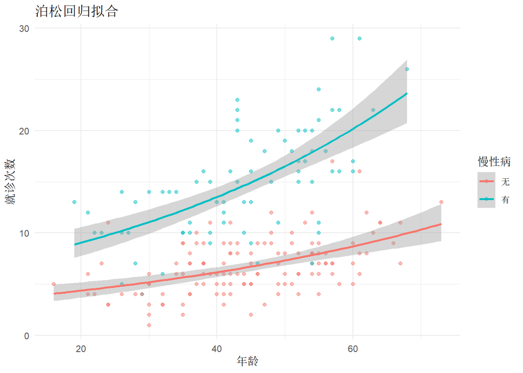

```r
# 预测
visit_data$pred_visits <- predict(model_pois, type = "response")

# 可视化
ggplot2::ggplot(visit_data, ggplot2::aes(x = age, y = visits, color = chronic_disease)) +
  ggplot2::geom_point(alpha = 0.5) +
  ggplot2::geom_smooth(method = "glm", method.args = list(family = "poisson"), se = TRUE) +
  ggplot2::labs(title = "泊松回归拟合", x = "年龄", y = "就诊次数", color = "慢性病") +
  ggplot2::theme_minimal()
```

## 2.7 负二项回归

### 意义与使用场景

**核心意义**：负二项回归用于处理过度离散的计数数据（方差大于均值），是泊松回归的重要扩展。

**举例**：研究年龄、慢性病对急诊就诊次数的影响

**为什么这种数据适合用负二项回归？**

首先，因变量”急诊就诊次数”是计数数据，但急诊就诊行为存在较大异质性：大多数患者一年内急诊就诊0-1次，少数患者因病情复杂频繁就诊（10次以上）。其次，这种异质性导致方差远大于均值（如均值=2，方差=15），违反泊松分布假设。负二项回归通过引入离散参数，允许方差大于均值，能够更好地拟合这种过度离散的计数数据。

**研究目的是什么？**

本研究有三个层次的目的：1. 识别就诊相关因素：判断哪些因素与急诊就诊次数相关；2. 处理过度离散：通过负二项回归正确估计标准误，避免假阳性结果；3. 比较模型优劣：通过AIC比较泊松回归与负二项回归，选择更优模型。

**可能得到什么样的结果？**

假设数据诊断显示：均值=2.3，方差=12.8，方差/均值=5.6（明显过度离散）。

1. 泊松回归AIC=1250，负二项回归AIC=980，负二项回归更优。
2. 年龄效应：IRR=1.03，年龄每增加1岁，急诊就诊次数增加3%。
3. 慢性病效应：IRR=2.5，有慢性病者急诊就诊次数是无慢性病者的2.5倍。
4. 离散参数：θ=1.5，表明存在显著的过度离散，负二项回归的选择是正确的。

**需要注意什么？**

负二项回归适用于过度离散的计数数据，但需要正确识别过度离散。诊断方法：方差/均值比>1，残差偏差/自由度>>1，或使用Cameron-Trivedi检验。当离散参数θ趋向无穷大时，负二项回归退化为泊松回归。若数据不存在过度离散，使用泊松回归即可。

### 数学基础

**负二项回归**：

当计数数据存在过度离散（方差 > 均值）时，泊松回归不再适用，应使用负二项回归。

**负二项分布**：
$$P(Y = y) =
\frac{\Gamma(y + \theta)}{\Gamma(\theta) y!} \left(\frac{\theta}{\theta
+ \mu}\right)^\theta \left(\frac{\mu}{\theta +
\mu}\right)^y$$

**参数说明**： - $\mu$：均值 - $\theta$：离散参数（$\theta \to \infty$时退化为泊松分布） - $Var(Y) = \mu + \mu^2/\theta$

**模型形式**：
$$\log(\mu) =
\beta_0 + \beta_1 X_1 + \cdots + \beta_p X_p$$

### 代码实现

```r
# 模拟过度离散的计数数据
set.seed(789)
n_nb <- 200

# 生成自变量
age_nb <- round(rnorm(n_nb, mean = 45, sd = 12))
chronic_nb <- rbinom(n_nb, 1, 0.4)

# 生成过度离散的计数数据
# 使用负二项分布
theta <- 2  # 离散参数
mu <- exp(1 + 0.02 * age_nb + 0.8 * chronic_nb)
visits_nb <- rnbinom(n_nb, size = theta, mu = mu)

# 创建数据框
visit_nb_data <- data.frame(
  age = age_nb,
  chronic_disease = factor(chronic_nb, levels = c(0, 1), labels = c("无", "有")),
  visits = visits_nb
)

# 检查过度离散
cat("========== 过度离散检验 ==========\n")
```

```
## ========== 过度离散检验 ==========
```

```r
cat(sprintf("均值 = %.2f, 方差 = %.2f\n", mean(visit_nb_data$visits), var(visit_nb_data$visits)))
```

```
## 均值 = 10.39, 方差 = 102.03
```

```r
cat(sprintf("方差/均值 = %.2f (> 1 表示过度离散)\n", var(visit_nb_data$visits) / mean(visit_nb_data$visits)))
```

```
## 方差/均值 = 9.82 (> 1 表示过度离散)
```

```r
# 拟合泊松回归（用于比较）
model_pois_nb <- glm(visits ~ age + chronic_disease,
                      data = visit_nb_data,
                      family = poisson(link = "log"))

# 拟合负二项回归
library(MASS)
model_nb <- MASS::glm.nb(visits ~ age + chronic_disease, data = visit_nb_data)

# 比较两个模型
cat("\n========== 泊松回归 vs 负二项回归 ==========\n")
```

```
##
## ========== 泊松回归 vs 负二项回归 ==========
```

```r
cat(sprintf("泊松回归 AIC: %.2f\n", AIC(model_pois_nb)))
```

```
## 泊松回归 AIC: 1762.00
```

```r
cat(sprintf("负二项回归 AIC: %.2f\n", AIC(model_nb)))
```

```
## 负二项回归 AIC: 1268.48
```

```r
# 负二项回归结果
summary(model_nb)
```

```
##
## Call:
## MASS::glm.nb(formula = visits ~ age + chronic_disease, data = visit_nb_data,
##     init.theta = 2.438268553, link = log)
##
## Coefficients:
##                   Estimate Std. Error z value Pr(>|z|)
## (Intercept)       0.842826   0.211872   3.978 6.95e-05 ***
## age               0.022689   0.004335   5.234 1.66e-07 ***
## chronic_disease有 0.905569   0.104174   8.693  < 2e-16 ***
## ---
## Signif. codes:  0 '***' 0.001 '**' 0.01 '*' 0.05 '.' 0.1 ' ' 1
##
## (Dispersion parameter for Negative Binomial(2.4383) family taken to be 1)
##
##     Null deviance: 317.37  on 199  degrees of freedom
## Residual deviance: 216.24  on 197  degrees of freedom
## AIC: 1268.5
##
## Number of Fisher Scoring iterations: 1
##
##
##               Theta:  2.438
##           Std. Err.:  0.312
##
##  2 x log-likelihood:  -1260.484
```

```r
# 提取系数和IRR
coef_nb <- broom::tidy(model_nb, conf.int = TRUE, exponentiate = TRUE)
cat("\n========== 负二项回归IRR ==========\n")
```

```
##
## ========== 负二项回归IRR ==========
```

```r
print(coef_nb)
```

```
## # A tibble: 3 × 7
##   term              estimate std.error statistic  p.value conf.low conf.high
##   <chr>                <dbl>     <dbl>     <dbl>    <dbl>    <dbl>     <dbl>
## 1 (Intercept)           2.32   0.212        3.98 6.95e- 5     1.56      3.45
## 2 age                   1.02   0.00434      5.23 1.66e- 7     1.01      1.03
## 3 chronic_disease有     2.47   0.104        8.69 3.53e-18     2.02      3.04
```

```r
# 离散参数
cat(sprintf("\n离散参数 theta = %.3f\n", model_nb$theta))
```

```
##
## 离散参数 theta = 2.438
```

## 2.8 准似然与过度离散

### 意义与使用场景

**核心意义**：准似然方法通过引入离散参数，放宽对分布的严格假设，提供更稳健的标准误估计。

**举例**：临床试验中研究治疗组对不良事件发生次数的影响

**为什么这种数据适合用准似然方法？**

首先，临床试验中的不良事件计数数据可能存在轻度过度离散（方差略大于均值），但样本量有限，难以精确估计离散参数。其次，负二项回归需要估计额外的离散参数，在小样本情况下可能不稳定。准泊松模型保持泊松回归的结构，仅通过离散参数调整标准误估计，是一种更稳健的折中方案。这种”轻度过度离散+小样本”的场景，适合使用准似然方法。

**研究目的是什么？**

本研究有三个层次的目的：1. 检验过度离散：判断数据是否存在过度离散，程度如何；2. 稳健推断：通过准泊松模型获得稳健的标准误和置信区间；3. 模型比较：比较泊松、准泊松、负二项三种方法的适用性。

**可能得到什么样的结果？**

假设数据诊断显示：均值=3.5，方差=5.8，残差偏差/自由度=1.65（轻度过度离散）。

1. 过度离散检验：离散参数φ=1.65，存在轻度过度离散。
2. 标准误调整：准泊松模型的标准误是泊松模型的√1.65=1.28倍，置信区间更宽。
3. 系数比较：泊松回归和准泊松回归的点估计相同，但准泊松的p值更大（更保守）。
4. 方法选择：轻度过度离散时，准泊松模型足够稳健；重度过度离散时，负二项回归更优。

**需要注意什么？**

准泊松模型仅调整标准误估计，不改变点估计，适用于轻度过度离散的情况。当过度离散严重时（φ>2），建议使用负二项回归。准泊松模型无法用于预测（没有完整的似然函数），仅适用于推断目的。此外，准似然方法也可用于二项分布的过度离散问题（准二项模型）。

### 数学基础

**过度离散（Overdispersion）**：

当数据的方差大于模型假设的方差时，称为过度离散。

**检验方法**：

1. **偏差/自由度比**：若$Deviance/df >> 1$，存在过度离散
2. **Pearson卡方/自由度比**：若$\chi^2/df >> 1$，存在过度离散
3. **Cameron-Trivedi检验**

**准泊松模型**：

引入离散参数$\phi$：
$$Var(Y) = \phi \cdot \mu$$

**参数说明**： - $\phi = 1$：泊松模型 - $\phi > 1$：过度离散 - $\phi < 1$：欠离散

### 代码实现

```r
# 检验泊松回归的过度离散
# 计算偏差/自由度比
deviance_df <- deviance(model_pois_nb) / model_pois_nb$df.residual
cat(sprintf("偏差/自由度 = %.2f\n", deviance_df))
```

```
## 偏差/自由度 = 5.10
```

```r
# Pearson卡方/自由度比
pearson_chi2 <- sum(residuals(model_pois_nb, type = "pearson")^2)
pearson_df <- pearson_chi2 / model_pois_nb$df.residual
cat(sprintf("Pearson卡方/自由度 = %.2f\n", pearson_df))
```

```
## Pearson卡方/自由度 = 5.40
```

```r
# 拟合准泊松模型
model_quasi <- glm(visits ~ age + chronic_disease,
                   data = visit_nb_data,
                   family = quasipoisson(link = "log"))

summary(model_quasi)
```

```
##
## Call:
## glm(formula = visits ~ age + chronic_disease, family = quasipoisson(link = "log"),
##     data = visit_nb_data)
##
## Coefficients:
##                   Estimate Std. Error t value Pr(>|t|)
## (Intercept)       0.712800   0.219886   3.242   0.0014 **
## age               0.025531   0.004192   6.091 5.78e-09 ***
## chronic_disease有 0.903635   0.104709   8.630 2.05e-15 ***
## ---
## Signif. codes:  0 '***' 0.001 '**' 0.01 '*' 0.05 '.' 0.1 ' ' 1
##
## (Dispersion parameter for quasipoisson family taken to be 5.395892)
##
##     Null deviance: 1569.2  on 199  degrees of freedom
## Residual deviance: 1005.5  on 197  degrees of freedom
## AIC: NA
##
## Number of Fisher Scoring iterations: 5
```

```r
# 提取离散参数
dispersion <- summary(model_quasi)$dispersion
cat(sprintf("\n离散参数 phi = %.2f\n", dispersion))
```

```
##
## 离散参数 phi = 5.40
```

```r
# 比较标准误
se_compare <- data.frame(
  Variable = c("age", "chronic_disease有"),
  Poisson_SE = summary(model_pois_nb)$coefficients[2:3, 2],
  QuasiPoisson_SE = summary(model_quasi)$coefficients[2:3, 2],
  NegBin_SE = summary(model_nb)$coefficients[2:3, 2]
)
cat("\n========== 标准误比较 ==========\n")
```

```
##
## ========== 标准误比较 ==========
```

```r
print(se_compare)
```

```
##                            Variable  Poisson_SE QuasiPoisson_SE   NegBin_SE
## age                             age 0.001804453     0.004191574 0.004335222
## chronic_disease有 chronic_disease有 0.045076728     0.104708996 0.104173940
```

## 2.9 模型诊断

### 意义与使用场景

**核心意义**：GLM诊断用于评估模型拟合质量、识别异常值和影响点，确保模型结论的可靠性。

**举例**：对糖尿病预测的逻辑回归模型进行诊断

**为什么这种数据适合用模型诊断？**

首先，GLM模型（如逻辑回归）虽然放宽了线性回归的部分假设，但仍需满足一些条件：链接函数正确、无严重异常值、无高影响点。其次，医疗数据中可能存在数据录入错误、特殊病例或极端特征患者，这些异常观测可能扭曲模型结果。模型诊断能够系统性地识别这些问题，确保模型结论的可靠性。

**研究目的是什么？**

本研究有三个层次的目的：1. 评估拟合质量：通过偏差残差、伪R²等指标评估模型整体拟合效果；2. 识别异常观测：发现偏离模型预测较大的数据点，可能是数据错误或特殊病例；3. 识别影响点：判断哪些观测对模型参数估计有重大影响。

**可能得到什么样的结果？**

假设诊断结果显示：偏差残差范围[-2.5, 3.2]，伪R²=0.45，第156号观测Cook距离=0.8。

1. 拟合质量：伪R²=0.45，模型解释了45%的变异，拟合效果中等。
2. 异常值识别：3个观测的偏差残差绝对值>2，需要检查是否为数据错误。
3. 影响点诊断：第156号观测Cook距离=0.8（阈值4/n=0.013），删除后年龄系数从0.05变为0.03。
4. 改进建议：检查第156号观测的数据质量，考虑是否需要特殊处理。

**需要注意什么？**

GLM诊断与线性回归诊断有所不同：残差的正态性不再是核心假设，但偏差残差的分布仍可用于识别异常值。伪R²的解释与线性回归的R²不同，不能直接比较。Cook距离在GLM中的阈值需要谨慎设定，通常使用4/n或更严格的1/n。

### 数学基础

**GLM诊断指标**：

| 指标 | 公式 | 用途 |
| --- | --- | --- |
| 偏差残差 | $r_D = \text{sign}(y-\hat{\mu})\sqrt{d_i}$ | 整体拟合评估 |
| Pearson残差 | $r_P = \frac{y-\hat{\mu}}{\sqrt{V(\hat{\mu})}}$ | 异常值识别 |
| 帽子值 | $h_{ii}$ | 杠杆值 |

**偏差（Deviance）**：
$$D =
2\sum_{i=1}^{n} \left[ y_i \log\left(\frac{y_i}{\hat{\mu}_i}\right) -
(y_i - \hat{\mu}_i) \right]$$

**拟合优度检验**：
$$\chi^2 =
\frac{D}{\phi} \sim \chi^2_{n-p-1}$$

### 代码实现

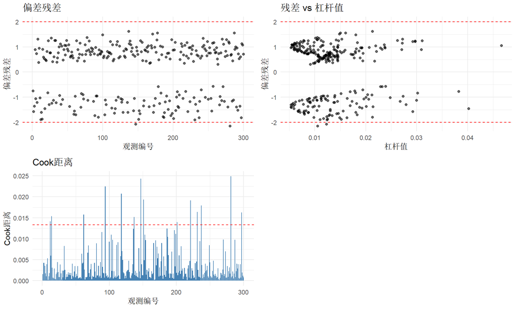

```r
# 使用逻辑回归模型进行诊断
# 偏差残差
dev_resid <- residuals(model_logit, type = "deviance")
# Pearson残差
pear_resid <- residuals(model_logit, type = "pearson")
# 帽子值
hat_values <- hatvalues(model_logit)
# Cook距离
cook_d <- cooks.distance(model_logit)

# 创建诊断数据框
diag_glm <- data.frame(
  obs = 1:length(dev_resid),
  dev_resid = dev_resid,
  pear_resid = pear_resid,
  hat = hat_values,
  cook_d = cook_d
)

# 可视化
p1 <- ggplot2::ggplot(diag_glm, ggplot2::aes(x = obs, y = dev_resid)) +
  ggplot2::geom_point(alpha = 0.6) +
  ggplot2::geom_hline(yintercept = c(-2, 2), color = "red", linetype = "dashed") +
  ggplot2::labs(title = "偏差残差", x = "观测编号", y = "偏差残差") +
  ggplot2::theme_minimal()

p2 <- ggplot2::ggplot(diag_glm, ggplot2::aes(x = hat, y = dev_resid)) +
  ggplot2::geom_point(alpha = 0.6) +
  ggplot2::geom_hline(yintercept = c(-2, 2), color = "red", linetype = "dashed") +
  ggplot2::labs(title = "残差 vs 杠杆值", x = "杠杆值", y = "偏差残差") +
  ggplot2::theme_minimal()

p3 <- ggplot2::ggplot(diag_glm, ggplot2::aes(x = obs, y = cook_d)) +
  ggplot2::geom_bar(stat = "identity", fill = "steelblue") +
  ggplot2::geom_hline(yintercept = 4/nrow(diag_glm), color = "red", linetype = "dashed") +
  ggplot2::labs(title = "Cook距离", x = "观测编号", y = "Cook距离") +
  ggplot2::theme_minimal()

gridExtra::grid.arrange(p1, p2, p3, ncol = 2)
```

```r
# 模型拟合优度
cat("========== 模型拟合优度 ==========\n")
```

```
## ========== 模型拟合优度 ==========
```

```r
cat(sprintf("空模型偏差: %.2f (df = %d)\n", model_logit$null.deviance, model_logit$df.null))
```

```
## 空模型偏差: 390.89 (df = 299)
```

```r
cat(sprintf("残差偏差: %.2f (df = %d)\n", deviance(model_logit), model_logit$df.residual))
```

```
## 残差偏差: 349.43 (df = 296)
```

```r
cat(sprintf("偏差减少: %.2f%%\n",
            (model_logit$null.deviance - deviance(model_logit)) / model_logit$null.deviance * 100))
```

```
## 偏差减少: 10.60%
```

```r
# 伪R²
library(DescTools)
pseudo_r2 <- DescTools::PseudoR2(model_logit, which = "all")
cat("\n========== 伪R² ==========\n")
```

```
##
## ========== 伪R² ==========
```

```r
print(pseudo_r2)
```

```
##        McFadden     McFaddenAdj        CoxSnell      Nagelkerke   AldrichNelson
##      0.10604569      0.08557935      0.12905154      0.17720249      0.12139854
## VeallZimmermann           Efron McKelveyZavoina            Tjur             AIC
##      0.21457044      0.13102015      0.18490199      0.13155901    357.43395741
##             BIC          logLik         logLik0              G2
##    372.24908731   -174.71697871   -195.44285065     41.45174389
```

## 2.10 零膨胀模型

### 意义与使用场景

**核心意义**：零膨胀模型用于处理零值比例过高的计数数据，将零值分解为”结构性零”和”抽样零”两部分。

**举例**：研究年龄、吸烟状态对每日吸烟支数的影响

**为什么这种数据适合用零膨胀模型？**

首先，因变量”每日吸烟支数”是计数数据，但存在大量零值：非吸烟者每日吸烟支数为0（结构性零），吸烟者偶尔也可能某天不吸烟（抽样零）。其次，标准泊松/负二项回归无法解释过多的零值，会低估零的概率，导致模型拟合不佳。零膨胀模型将零值分解为两部分：结构性零（从不吸烟者）由logit模型解释，抽样零（吸烟者偶尔不吸烟）由计数模型解释。

**研究目的是什么？**

本研究有三个层次的目的：1. 区分零的来源：识别哪些零是结构性零（非吸烟者），哪些是抽样零（吸烟者偶尔不吸烟）；2. 分析影响因素：分别分析影响”是否吸烟”和”吸烟量”的因素；3. 改善模型拟合：通过零膨胀模型更好地拟合零值过多的计数数据。

**可能得到什么样的结果？**

假设ZIP模型结果显示：零膨胀部分年龄OR=0.95，计数部分年龄IRR=1.02。

1. 零膨胀部分：年龄OR=0.95，年龄越大，成为吸烟者的概率越低（结构性零概率越高）。
2. 计数部分：年龄IRR=1.02，在吸烟者中，年龄越大，每日吸烟支数越多。
3. 模型比较：ZIP模型AIC=850，泊松回归AIC=1200，ZIP模型拟合更优。
4. 临床意义：年龄对吸烟行为有双重作用——降低吸烟概率，但增加吸烟量。

**需要注意什么？**

零膨胀模型适用于零值比例远高于理论预期的情况。诊断方法：比较实际零值比例与泊松/负二项分布预测的零值比例。若零值比例接近理论预期，使用标准计数模型即可。此外，零膨胀模型需要足够样本量来同时估计两部分参数。模型选择：ZIP适用于无过度离散的数据，ZINB适用于过度离散的数据。

### 数学基础

**零膨胀模型（Zero-Inflated Models）**：

当计数数据中零值比例过高时使用，由两部分组成： 1. **零膨胀部分**：Logit/Probit模型预测零的概率 2. **计数部分**：泊松/负二项模型预测计数

**零膨胀泊松模型（ZIP）**：
$$P(Y = 0) = \pi + (1-\pi)e^{-\lambda}$$
$$P(Y = y) =
(1-\pi)\frac{e^{-\lambda}\lambda^y}{y!}, \quad y = 1, 2,
\ldots$$

**参数说明**： - $\pi$：额外零的概率 - $\lambda$：泊松分布的均值

### 代码实现

```r
# 模拟零膨胀数据
set.seed(890)
n_zip <- 200

# 生成自变量
age_zip <- round(rnorm(n_zip, mean = 45, sd = 10))
smoking <- rbinom(n_zip, 1, 0.3)  # 吸烟（0=否，1=是）

# 零膨胀部分：某些人从不就诊
pi_zero <- 1 / (1 + exp(-(-1 + 0.02 * age_zip - 0.5 * smoking)))
always_zero <- rbinom(n_zip, 1, pi_zero)

# 计数部分：就诊次数
lambda_zip <- exp(1 + 0.02 * age_zip + 0.5 * smoking)
visits_zip <- ifelse(always_zero == 1, 0, rpois(n_zip, lambda_zip))

# 创建数据框
zip_data <- data.frame(
  age = age_zip,
  smoking = factor(smoking, levels = c(0, 1), labels = c("否", "是")),
  visits = visits_zip
)

# 检查零的比例
cat("========== 零值比例 ==========\n")
```

```
## ========== 零值比例 ==========
```

```r
cat(sprintf("零值比例: %.2f%%\n", mean(zip_data$visits == 0) * 100))
```

```
## 零值比例: 40.50%
```

```r
# 拟合标准泊松回归
model_pois_zip <- glm(visits ~ age + smoking,
                       data = zip_data,
                       family = poisson(link = "log"))

# 拟合零膨胀泊松模型
library(pscl)
model_zip <- pscl::zeroinfl(visits ~ age + smoking | age + smoking,
                             data = zip_data, dist = "poisson")

# 拟合零膨胀负二项模型
model_zinb <- pscl::zeroinfl(visits ~ age + smoking | age + smoking,
                              data = zip_data, dist = "negbin")

# 比较模型
cat("\n========== 模型比较 ==========\n")
```

```
##
## ========== 模型比较 ==========
```

```r
cat(sprintf("泊松回归 AIC: %.2f\n", AIC(model_pois_zip)))
```

```
## 泊松回归 AIC: 1615.55
```

```r
cat(sprintf("ZIP AIC: %.2f\n", AIC(model_zip)))
```

```
## ZIP AIC: 868.63
```

```r
cat(sprintf("ZINB AIC: %.2f\n", AIC(model_zinb)))
```

```
## ZINB AIC: 869.90
```

```r
# ZIP模型结果
summary(model_zip)
```

```
##
## Call:
## pscl::zeroinfl(formula = visits ~ age + smoking | age + smoking, data = zip_data,
##     dist = "poisson")
##
## Pearson residuals:
##     Min      1Q  Median      3Q     Max
## -1.2869 -1.0096  0.0846  0.7865  2.6706
##
## Count model coefficients (poisson with log link):
##             Estimate Std. Error z value Pr(>|z|)
## (Intercept) 1.035651   0.147349   7.029 2.09e-12 ***
## age         0.017400   0.002956   5.887 3.94e-09 ***
## smoking是   0.670040   0.064255  10.428  < 2e-16 ***
##
## Zero-inflation model coefficients (binomial with logit link):
##             Estimate Std. Error z value Pr(>|z|)
## (Intercept) -1.14994    0.66958  -1.717   0.0859 .
## age          0.01726    0.01395   1.237   0.2160
## smoking是   -0.13637    0.31804  -0.429   0.6681
## ---
## Signif. codes:  0 '***' 0.001 '**' 0.01 '*' 0.05 '.' 0.1 ' ' 1
##
## Number of iterations in BFGS optimization: 11
## Log-likelihood: -428.3 on 6 Df
```

```r
# 提取系数
cat("\n========== ZIP模型系数 ==========\n")
```

```
##
## ========== ZIP模型系数 ==========
```

```r
cat("计数部分（泊松）IRR：\n")
```

```
## 计数部分（泊松）IRR：
```

```r
print(exp(coef(model_zip, model = "count")))
```

```
## (Intercept)         age   smoking是
##    2.816940    1.017552    1.954316
```

```r
cat("\n零膨胀部分（logit）OR：\n")
```

```
##
## 零膨胀部分（logit）OR：
```

```r
print(exp(coef(model_zip, model = "zero")))
```

```
## (Intercept)         age   smoking是
##   0.3166568   1.0174080   0.8725219
```

## 第二章小结

### 核心知识点总结

| 主题 | 核心内容 | 关键函数 |
| --- | --- | --- |
| 指数族分布 | GLM的理论基础 | `dnorm()`, `dbinom()`, `dpois()` |
| 链接函数 | 连接均值与线性预测器 | `glm(family = ...)` |
| 逻辑回归 | 二分类因变量 | `glm(family = binomial)` |
| 多项逻辑回归 | 无序多分类 | `nnet::multinom()` |
| 序数逻辑回归 | 有序多分类 | `MASS::polr()` |
| 泊松回归 | 计数数据 | `glm(family = poisson)` |
| 负二项回归 | 过度离散计数 | `MASS::glm.nb()` |
| 准泊松模型 | 过度离散校正 | `glm(family = quasipoisson)` |
| 零膨胀模型 | 过多零值的计数 | `pscl::zeroinfl()` |

# 第三章：混合效应模型

混合效应模型（Mixed Effects Models）用于处理具有层次结构或聚类特征的数据，如患者嵌套在医院中、重复测量数据等。本章将系统讲解线性混合模型和广义线性混合模型的理论与应用。

## 3.1 线性混合模型的基本结构

### 意义与使用场景

**核心意义**：线性混合模型用于处理具有层次结构或聚类特征的数据，通过引入随机效应来捕捉组间异质性。

**举例**：多中心临床试验中研究治疗对血压的影响

**为什么这种数据适合用线性混合模型？**

首先，数据具有层次结构：患者嵌套在医院中，同一医院的患者可能具有相似的特征（如相似的医疗水平、护理质量）。其次，传统线性回归假设观测独立，忽略了层次结构，会导致标准误低估、假阳性增加。线性混合模型通过引入随机效应（医院效应），能够正确处理层次结构数据，同时估计组间和组内效应。

**研究目的是什么？**

本研究有三个层次的目的：1. 估计治疗效果：在控制医院间差异后，准确估计治疗对血压的影响；2. 量化医院异质性：通过随机效应方差估计医院间的差异程度；3. 正确推断：获得稳健的标准误和置信区间，避免假阳性结果。

**可能得到什么样的结果？**

假设模型结果显示：治疗组系数=-10.2（p<0.001），医院随机效应方差=64，残差方差=100。

1. 治疗效应：治疗组比对照组血压平均降低10.2 mmHg，差异显著。
2. 医院异质性：医院间方差=64，说明不同医院的基础血压水平存在差异（标准差=8 mmHg）。
3. 组内相关系数：ICC=64/(64+100)=0.39，39%的变异来自医院间差异。
4. 标准误校正：与传统回归相比，混合模型的标准误更大，推断更稳健。

**需要注意什么？**

线性混合模型假设随机效应服从正态分布，当组数较少（<10组）时，随机效应估计可能不稳定。此外，需要区分固定效应和随机效应的选择：关注特定组效应时用固定效应，关注总体效应时用随机效应。模型选择可通过似然比检验或AIC比较。

### 数学基础

**线性混合模型（Linear Mixed Model, LMM）**：

包含固定效应和随机效应的线性模型。

**模型形式**：
$$Y_{ij} =
\underbrace{\mathbf{X}_{ij}'\boldsymbol{\beta}}_{\text{固定效应}} +
\underbrace{\mathbf{Z}_{ij}'\mathbf{b}_i}_{\text{随机效应}} +
\varepsilon_{ij}$$

**矩阵形式**：
$$\mathbf{Y} =
\mathbf{X}\boldsymbol{\beta} + \mathbf{Z}\mathbf{b} +
\boldsymbol{\varepsilon}$$

**参数说明**： - $Y_{ij}$：第$i$组第$j$个观测的因变量 - $\mathbf{X}_{ij}$：固定效应设计矩阵 - $\boldsymbol{\beta}$：固定效应系数 - $\mathbf{Z}_{ij}$：随机效应设计矩阵 - $\mathbf{b}_i$：第$i$组的随机效应，$\mathbf{b}_i \sim N(\mathbf{0}, \mathbf{D})$ - $\varepsilon_{ij}$：残差，$\varepsilon_{ij} \sim N(0, \sigma^2)$

**随机效应的假设**：
$$\mathbf{b} \sim N(\mathbf{0}, \mathbf{G}), \quad
\boldsymbol{\varepsilon} \sim N(\mathbf{0}, \mathbf{R})$$

**边际方差**：
$$Var(\mathbf{Y}) =
\mathbf{Z}\mathbf{G}\mathbf{Z}' + \mathbf{R}$$

### 代码实现

```r
# 模拟嵌套数据：患者嵌套在医院中
# 场景：研究不同医院患者的血压控制情况

set.seed(123)
n_hospitals <- 20          # 医院数量
n_per_hospital <- 15       # 每个医院的患者数
n_total <- n_hospitals * n_per_hospital

# 生成医院ID
hospital_id <- factor(rep(1:n_hospitals, each = n_per_hospital))

# 生成医院级别的随机效应（不同医院的基础血压水平不同）
hospital_effect <- rnorm(n_hospitals, mean = 0, sd = 8)
hospital_effect_expanded <- hospital_effect[as.numeric(hospital_id)]

# 生成患者级别的自变量
age_lmm <- round(rnorm(n_total, mean = 55, sd = 12))
treatment <- rbinom(n_total, 1, 0.5)  # 治疗组（0=对照，1=治疗）

# 生成因变量：收缩压
# 固定效应：年龄、治疗
# 随机效应：医院截距
bp <- 120 + 0.5 * age_lmm - 10 * treatment + hospital_effect_expanded + rnorm(n_total, 0, 10)

# 创建数据框
bp_data <- data.frame(
  patient_id = 1:n_total,
  hospital = hospital_id,
  age = age_lmm,
  treatment = factor(treatment, levels = c(0, 1), labels = c("对照", "治疗")),
  bp = bp
)

# 查看数据结构
str(bp_data)
```

```
## 'data.frame':    300 obs. of  5 variables:
##  $ patient_id: int  1 2 3 4 5 6 7 8 9 10 ...
##  $ hospital  : Factor w/ 20 levels "1","2","3","4",..: 1 1 1 1 1 1 1 1 1 1 ...
##  $ age       : num  42 52 43 46 47 35 65 57 41 70 ...
##  $ treatment : Factor w/ 2 levels "对照","治疗": 2 2 2 1 1 2 2 1 1 2 ...
##  $ bp        : num  146 129 114 136 137 ...
```

```r
head(bp_data)
```

```
##   patient_id hospital age treatment       bp
## 1          1        1  42      治疗 146.2704
## 2          2        1  52      治疗 128.7014
## 3          3        1  43      治疗 113.7867
## 4          4        1  46      对照 136.1227
## 5          5        1  47      对照 136.8758
## 6          6        1  35      治疗 124.5330
```

```r
# 描述性统计：按医院汇总
hospital_summary <- bp_data %>%
  dplyr::group_by(hospital) %>%
  dplyr::summarise(
    n = dplyr::n(),
    mean_bp = mean(bp),
    sd_bp = sd(bp)
  )
print(hospital_summary)
```

```
## # A tibble: 20 × 4
##    hospital     n mean_bp sd_bp
##    <fct>    <int>   <dbl> <dbl>
##  1 1           15    138. 11.6
##  2 2           15    142.  7.68
##  3 3           15    152. 12.2
##  4 4           15    145. 10.3
##  5 5           15    147. 11.6
##  6 6           15    156. 12.6
##  7 7           15    144.  9.55
##  8 8           15    131. 13.9
##  9 9           15    134. 13.4
## 10 10          15    138. 11.8
## 11 11          15    153. 12.8
## 12 12          15    145. 12.9
## 13 13          15    148. 16.5
## 14 14          15    139.  8.69
## 15 15          15    134. 15.3
## 16 16          15    155. 14.3
## 17 17          15    148. 14.1
## 18 18          15    129.  9.13
## 19 19          15    155. 17.9
## 20 20          15    140. 13.2
```

## 3.2 随机截距与随机斜率

### 意义与使用场景

**核心意义**：随机截距允许不同组有不同的基线水平，随机斜率允许不同组有不同的效应大小。

**举例**：研究不同医院治疗效果的异质性

**为什么这种数据适合用随机斜率模型？**

首先，不同医院的基础血压水平可能不同（随机截距）：三甲医院患者可能病情更重，社区医院患者可能病情较轻。其次，不同医院的治疗效果可能存在差异（随机斜率）：三甲医院设备先进、医生经验丰富，治疗效果可能更好；社区医院资源有限，治疗效果可能较弱。随机斜率模型能够捕捉这种”治疗效果因医院而异”的异质性。

**研究目的是什么？**

本研究有三个层次的目的：1. 估计平均治疗效果：在考虑医院异质性后，估计总体治疗效果；2. 识别效果异质性：判断治疗效果是否在不同医院间存在显著差异；3. 模型选择：通过似然比检验比较随机截距模型与随机斜率模型。

**可能得到什么样的结果？**

假设随机斜率模型显示：平均治疗效果=-10 mmHg，治疗效果随机斜率方差=25（标准差=5 mmHg）。

1. 平均效应：总体而言，治疗组比对照组血压降低10 mmHg。
2. 效果异质性：治疗效果的标准差为5 mmHg，说明不同医院的治疗效果存在差异。
3. 医院间比较：治疗效果最好的医院可能降低15 mmHg，最差的医院可能仅降低5 mmHg。
4. 模型比较：随机斜率模型AIC比随机截距模型小20，支持使用随机斜率模型。

**需要注意什么？**

随机斜率模型增加了参数数量，需要足够多的组（通常>20组）和每组足够的样本量。当随机斜率方差很小时，可能退化为随机截距模型。此外，随机截距和随机斜率可能存在相关性：基础水平高的医院，治疗效果可能更好或更差。模型选择应结合似然比检验和AIC。

### 数学基础

**随机截距模型**：

每个组有不同的截距，但斜率相同。

$$Y_{ij} = (\beta_0 + b_{0i}) + \beta_1
X_{ij} + \varepsilon_{ij}$$

**参数说明**： - $b_{0i}$：第$i$组的随机截距，$b_{0i} \sim N(0, \tau_{00}^2)$ - $\tau_{00}^2$：组间方差

**随机斜率模型**：

每个组有不同的截距和斜率。

$$Y_{ij} = (\beta_0 + b_{0i}) + (\beta_1 +
b_{1i}) X_{ij} + \varepsilon_{ij}$$

**参数说明**： - $b_{0i}$：随机截距 - $b_{1i}$：随机斜率，$b_{1i} \sim N(0, \tau_{11}^2)$ - $Cov(b_{0i}, b_{1i}) = \tau_{01}$

**组内相关系数（ICC）**：

$$ICC = \frac{\tau_{00}^2}{\tau_{00}^2 +
\sigma^2}$$

衡量组间方差占总方差的比例。

### 代码实现

```r
# 1. 随机截距模型
model_ri <- lme4::lmer(bp ~ age + treatment + (1 | hospital), data = bp_data)
summary(model_ri)
```

```
## Linear mixed model fit by REML ['lmerMod']
## Formula: bp ~ age + treatment + (1 | hospital)
##    Data: bp_data
##
## REML criterion at convergence: 2270.5
##
## Scaled residuals:
##     Min      1Q  Median      3Q     Max
## -2.8610 -0.5937 -0.0102  0.6330  2.6993
##
## Random effects:
##  Groups   Name        Variance Std.Dev.
##  hospital (Intercept) 55.96    7.481
##  Residual             98.86    9.943
## Number of obs: 300, groups:  hospital, 20
##
## Fixed effects:
##                Estimate Std. Error t value
## (Intercept)   119.72097    3.39868  35.226
## age             0.52535    0.05085  10.332
## treatment治疗  -9.82240    1.18110  -8.316
##
## Correlation of Fixed Effects:
```

```
##               (Intr) age
## age           -0.834
## treatment治疗 -0.216  0.040
```

```r
# 提取方差成分
vc_ri <- lme4::VarCorr(model_ri)
cat("\n========== 随机截距模型方差成分 ==========\n")
```

```
##
## ========== 随机截距模型方差成分 ==========
```

```r
print(vc_ri)
```

```
##  Groups   Name        Std.Dev.
##  hospital (Intercept) 7.4805
##  Residual             9.9431
```

```r
# 计算ICC
tau2 <- as.numeric(vc_ri$hospital)
sigma2 <- attr(vc_ri, "sc")^2
icc <- tau2 / (tau2 + sigma2)
cat(sprintf("\n组内相关系数(ICC) = %.3f\n", icc))
```

```
##
## 组内相关系数(ICC) = 0.361
```

```r
# 2. 随机斜率模型（允许治疗效果在不同医院间变化）
model_rs <- lme4::lmer(bp ~ age + treatment + (1 + treatment | hospital), data = bp_data)
summary(model_rs)
```

```
## Linear mixed model fit by REML ['lmerMod']
## Formula: bp ~ age + treatment + (1 + treatment | hospital)
##    Data: bp_data
##
## REML criterion at convergence: 2270.2
##
## Scaled residuals:
##     Min      1Q  Median      3Q     Max
## -2.8782 -0.6045 -0.0095  0.6442  2.6468
##
## Random effects:
##  Groups   Name          Variance Std.Dev. Corr
##  hospital (Intercept)   61.7953  7.8610
##           treatment治疗  0.5871  0.7662   -0.91
##  Residual               98.6958  9.9346
## Number of obs: 300, groups:  hospital, 20
##
## Fixed effects:
##               Estimate Std. Error t value
## (Intercept)   119.8866     3.4391  34.860
## age             0.5222     0.0508  10.280
## treatment治疗  -9.8202     1.1922  -8.237
##
## Correlation of Fixed Effects:
```

```
##               (Intr) age
## age           -0.824
## treatment治疗 -0.277  0.039
```

```r
# 提取方差成分
vc_rs <- lme4::VarCorr(model_rs)
cat("\n========== 随机斜率模型方差成分 ==========\n")
```

```
##
## ========== 随机斜率模型方差成分 ==========
```

```r
print(vc_rs)
```

```
##  Groups   Name          Std.Dev. Corr
##  hospital (Intercept)   7.86100
##           treatment治疗 0.76621  -0.905
##  Residual               9.93458
```

```r
# 比较模型
cat("\n========== 模型比较 ==========\n")
```

```
##
## ========== 模型比较 ==========
```

```r
cat(sprintf("随机截距模型 AIC: %.2f\n", AIC(model_ri)))
```

```
## 随机截距模型 AIC: 2280.47
```

```r
cat(sprintf("随机斜率模型 AIC: %.2f\n", AIC(model_rs)))
```

```
## 随机斜率模型 AIC: 2284.18
```

```r
# 似然比检验
anova(model_ri, model_rs)
```

```
## Data: bp_data
## Models:
## model_ri: bp ~ age + treatment + (1 | hospital)
## model_rs: bp ~ age + treatment + (1 + treatment | hospital)
##          npar    AIC    BIC  logLik -2*log(L)  Chisq Df Pr(>Chisq)
## model_ri    5 2281.5 2300.0 -1135.7    2271.5
## model_rs    7 2285.2 2311.1 -1135.6    2271.2 0.2861  2     0.8667
```

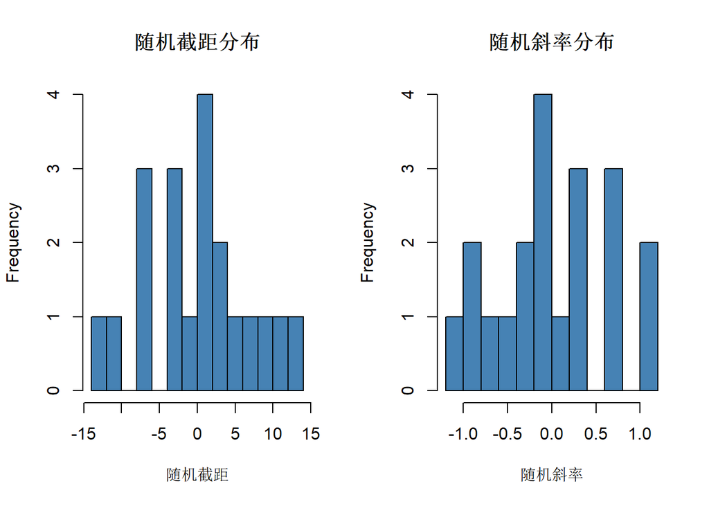

```r
# 可视化随机效应
# 提取随机效应
ranef_ri <- lme4::ranef(model_ri)$hospital
ranef_rs <- lme4::ranef(model_rs)$hospital

# 绘制随机截距分布
par(mfrow = c(1, 2))
hist(ranef_ri[, 1], main = "随机截距分布", xlab = "随机截距", col = "steelblue", breaks = 10)
hist(ranef_rs[, 2], main = "随机斜率分布", xlab = "随机斜率", col = "steelblue", breaks = 10)
```

```r
par(mfrow = c(1, 1))
```

## 3.3 嵌套与交叉设计

### 意义与使用场景

**核心意义**：嵌套设计处理层次结构数据，交叉设计处理多因素交叉影响的数据结构。

**举例**：研究医院质量改进项目对患者满意度的影响

**为什么这种数据适合用嵌套/交叉模型？**

首先，医疗数据常具有复杂结构：患者嵌套在病区，病区嵌套在医院（嵌套结构）；同时，患者可能接受不同医生、护士的治疗（交叉结构）。其次，忽略这种复杂结构会导致标准误估计错误。嵌套模型能够正确处理”患者→病区→医院”的层次关系；交叉模型能够处理”患者×医生”的交叉关系。

**研究目的是什么？**

本研究有三个层次的目的：1. 分解变异来源：量化医院、病区、患者各层次的变异大小；2. 正确建模：根据数据结构选择嵌套或交叉模型；3. 指导干预：根据变异来源确定质量改进的重点层次。

**可能得到什么样的结果？**

假设嵌套模型显示：医院间方差=25，病区间方差=16，患者间方差=9，残差方差=100。

1. 变异分解：总变异中，医院层次占17%，病区层次占11%，患者层次占6%，个体差异占66%。
2. 干预方向：医院和病区层次的变异占28%，说明质量改进应重点关注医院和病区层面。
3. ICC计算：医院层次ICC=25/(25+16+9+100)=0.17，同一医院患者满意度相关性为17%。
4. 交叉效应：若患者接受多个医生治疗，医生效应方差=12，说明医生间差异也是重要因素。

**需要注意什么？**

嵌套和交叉结构需要正确识别：嵌套关系中低层单位只属于一个高层单位（病区只属于一个医院）；交叉关系中单位可属于多个因素（患者可接受多个医生治疗）。模型设定错误会导致估计偏差。此外，交叉设计的模型更复杂，需要更多数据支持。

### 数学基础

**嵌套设计**：

低层次单位完全嵌套在高层次单位中。例如：学生嵌套在班级中，班级嵌套在学校中。

$$Y_{ijk} = \beta_0 + b_{0k}^{(school)} +
b_{0jk}^{(class)} + \varepsilon_{ijk}$$

**交叉设计**：

一个因素与多个其他因素交叉。例如：学生接受不同老师的课程。

$$Y_{ijk} = \beta_0 + b_{0i}^{(student)} +
b_{0j}^{(teacher)} + \varepsilon_{ijk}$$

### 代码实现

```r
# 嵌套设计示例：患者嵌套在病区，病区嵌套在医院
set.seed(456)
n_hospitals_nested <- 10
n_wards_per_hospital <- 3
n_patients_per_ward <- 8

# 生成嵌套ID
hospital_nested <- factor(rep(1:n_hospitals_nested, each = n_wards_per_hospital * n_patients_per_ward))
ward_nested <- factor(rep(1:(n_hospitals_nested * n_wards_per_hospital), each = n_patients_per_ward))

n_nested <- n_hospitals_nested * n_wards_per_hospital * n_patients_per_ward

# 生成随机效应
hospital_effect_nested <- rnorm(n_hospitals_nested, 0, 5)[as.numeric(hospital_nested)]
ward_effect_nested <- rnorm(n_hospitals_nested * n_wards_per_hospital, 0, 3)[as.numeric(ward_nested)]

# 生成数据
age_nested <- rnorm(n_nested, 50, 10)
outcome_nested <- 100 + 0.5 * age_nested + hospital_effect_nested + ward_effect_nested + rnorm(n_nested, 0, 5)

nested_data <- data.frame(
  hospital = hospital_nested,
  ward = ward_nested,
  age = age_nested,
  outcome = outcome_nested
)

# 拟合嵌套模型
model_nested <- lme4::lmer(outcome ~ age + (1 | hospital/ward), data = nested_data)
summary(model_nested)
```

```
## Linear mixed model fit by REML ['lmerMod']
## Formula: outcome ~ age + (1 | hospital/ward)
##    Data: nested_data
##
## REML criterion at convergence: 1504.9
##
## Scaled residuals:
##      Min       1Q   Median       3Q      Max
## -2.58442 -0.65975 -0.02934  0.63128  2.47259
##
## Random effects:
##  Groups        Name        Variance Std.Dev.
##  ward:hospital (Intercept) 11.86    3.444
##  hospital      (Intercept) 25.45    5.045
##  Residual                  23.44    4.842
## Number of obs: 240, groups:  ward:hospital, 30; hospital, 10
##
## Fixed effects:
##              Estimate Std. Error t value
## (Intercept) 100.15253    2.43530   41.12
## age           0.52205    0.03394   15.38
##
## Correlation of Fixed Effects:
##     (Intr)
## age -0.698
```

```r
# 查看方差成分
cat("\n========== 嵌套模型方差成分 ==========\n")
```

```
##
## ========== 嵌套模型方差成分 ==========
```

```r
print(lme4::VarCorr(model_nested))
```

```
##  Groups        Name        Std.Dev.
##  ward:hospital (Intercept) 3.4440
##  hospital      (Intercept) 5.0446
##  Residual                  4.8415
```

```r
# 交叉设计示例：患者接受不同医生的治疗
set.seed(789)
n_patients_cross <- 100
n_doctors <- 15

# 每个患者看多个医生，每个医生看多个患者（交叉）
patient_cross <- factor(rep(1:n_patients_cross, each = 3))
doctor_cross <- factor(sample(1:n_doctors, n_patients_cross * 3, replace = TRUE))

n_cross <- n_patients_cross * 3

# 生成随机效应
patient_effect <- rnorm(n_patients_cross, 0, 4)[as.numeric(patient_cross)]
doctor_effect <- rnorm(n_doctors, 0, 3)[as.numeric(doctor_cross)]

# 生成数据
time_cross <- rnorm(n_cross, 50, 10)
outcome_cross <- 100 + 0.3 * time_cross + patient_effect + doctor_effect + rnorm(n_cross, 0, 3)

cross_data <- data.frame(
  patient = patient_cross,
  doctor = doctor_cross,
  time = time_cross,
  outcome = outcome_cross
)

# 拟合交叉模型
model_cross <- lme4::lmer(outcome ~ time + (1 | patient) + (1 | doctor), data = cross_data)
summary(model_cross)
```

```
## Linear mixed model fit by REML ['lmerMod']
## Formula: outcome ~ time + (1 | patient) + (1 | doctor)
##    Data: cross_data
##
## REML criterion at convergence: 1749.8
##
## Scaled residuals:
##      Min       1Q   Median       3Q      Max
## -2.19933 -0.65035  0.09778  0.52889  2.39861
##
## Random effects:
##  Groups   Name        Variance Std.Dev.
##  patient  (Intercept) 15.904   3.988
##  doctor   (Intercept)  8.222   2.867
##  Residual              9.688   3.113
## Number of obs: 300, groups:  patient, 100; doctor, 15
##
## Fixed effects:
##              Estimate Std. Error t value
## (Intercept) 100.04146    1.44771   69.10
## time          0.28721    0.02301   12.48
##
## Correlation of Fixed Effects:
##      (Intr)
## time -0.804
```

```r
cat("\n========== 交叉模型方差成分 ==========\n")
```

```
##
## ========== 交叉模型方差成分 ==========
```

```r
print(lme4::VarCorr(model_cross))
```

```
##  Groups   Name        Std.Dev.
##  patient  (Intercept) 3.9880
##  doctor   (Intercept) 2.8674
##  Residual             3.1126
```

## 3.4 方差成分估计

### 意义与使用场景

**核心意义**：方差成分估计用于量化不同层次（组间、组内）的变异大小，是混合效应模型的核心。

**举例**：评估多中心临床试验中医院间变异的大小

**为什么这种数据适合用方差成分估计？**

首先，混合效应模型的核心是区分组间变异（随机效应方差）和组内变异（残差方差）。其次，方差成分估计能够回答关键问题：不同医院之间的差异有多大？同一医院内患者之间的差异有多大？这些信息对于理解数据结构、设计研究、解释结果都至关重要。

**研究目的是什么？**

本研究有三个层次的目的：1. 量化组间变异：估计医院间方差，判断医院异质性的程度；2. 计算ICC：组内相关系数反映同一医院患者相似程度；3. 指导研究设计：根据ICC确定样本量分配策略（更多医院还是更多患者）。

**可能得到什么样的结果？**

假设方差成分估计显示：医院间方差τ²=64，残差方差σ²=100，ICC=0.39。

1. 组间变异：医院间标准差=8 mmHg，说明不同医院的基础血压水平存在明显差异。
2. 组内相关：ICC=0.39，同一医院患者血压的相关性为39%，层次结构效应显著。
3. 设计效应：DEFF=1+(m-1)×ICC=1+14×0.39=6.46，有效样本量仅为名义样本量的1/6.46。
4. 样本量启示：增加医院数量比增加每医院患者数更有效。

**需要注意什么？**

方差成分估计方法有REML和ML两种：REML对方差的估计更准确，推荐用于最终模型；ML考虑固定效应损失自由度，适用于模型比较。当方差成分估计为0或接近0时，可能不需要随机效应。此外，小样本情况下方差估计可能不稳定，需要谨慎解释。

### 数学基础

**方差成分估计方法**：

| 方法 | 特点 | 适用场景 |
| --- | --- | --- |
| ANOVA方法 | 基于期望均方 | 平衡设计 |
| ML（极大似然） | 考虑固定效应损失 | 模型比较 |
| REML（限制极大似然） | 校正固定效应损失 | 方差估计（推荐） |

**REML vs ML**：

REML通过投影消除固定效应的影响，得到无偏的方差估计。

$$\ell_{REML}(\boldsymbol{\theta}) =
\ell_{ML}(\boldsymbol{\theta}) -
\frac{1}{2}\log|\mathbf{X}'\mathbf{V}^{-1}\mathbf{X}|$$

### 代码实现

```r
# 比较ML和REML估计
model_ml <- lme4::lmer(bp ~ age + treatment + (1 | hospital),
                        data = bp_data, REML = FALSE)
model_reml <- lme4::lmer(bp ~ age + treatment + (1 | hospital),
                          data = bp_data, REML = TRUE)

cat("========== ML估计 ==========\n")
```

```
## ========== ML估计 ==========
```

```r
print(lme4::VarCorr(model_ml))
```

```
##  Groups   Name        Std.Dev.
##  hospital (Intercept) 7.2696
##  Residual             9.9077
```

```r
cat("\n========== REML估计 ==========\n")
```

```
##
## ========== REML估计 ==========
```

```r
print(lme4::VarCorr(model_reml))
```

```
##  Groups   Name        Std.Dev.
##  hospital (Intercept) 7.4805
##  Residual             9.9431
```

```r
# 使用nlme包进行更灵活的建模
library(nlme)
model_nlme <- nlme::lme(bp ~ age + treatment,
                         random = ~ 1 | hospital,
                         data = bp_data,
                         method = "REML")
summary(model_nlme)
```

```
## Linear mixed-effects model fit by REML
##   Data: bp_data
##        AIC      BIC    logLik
##   2280.466 2298.935 -1135.233
##
## Random effects:
##  Formula: ~1 | hospital
##         (Intercept) Residual
## StdDev:    7.480538 9.943065
##
## Fixed effects:  bp ~ age + treatment
##                   Value Std.Error  DF  t-value p-value
## (Intercept)   119.72097  3.398680 278 35.22573       0
## age             0.52535  0.050848 278 10.33183       0
## treatment治疗  -9.82240  1.181105 278 -8.31628       0
##  Correlation:
```

```
##               (Intr) age
## age           -0.834
## treatment治疗 -0.216  0.040
##
## Standardized Within-Group Residuals:
##         Min          Q1         Med          Q3         Max
## -2.86099697 -0.59373342 -0.01019796  0.63300736  2.69928772
##
## Number of Observations: 300
## Number of Groups: 20
```

```r
# 提取方差成分
var_comp <- nlme::VarCorr(model_nlme)
print(var_comp)
```

```
## hospital = pdLogChol(1)
##             Variance StdDev
## (Intercept) 55.95845 7.480538
## Residual    98.86454 9.943065
```

## 3.5 广义线性混合模型

### 意义与使用场景

**核心意义**：广义线性混合模型（GLMM）结合了GLM和混合效应模型的优点，可处理非正态分布的层次结构数据。

**举例**：纵向研究中研究治疗对症状缓解的影响（二分类重复测量）

**为什么这种数据适合用广义线性混合模型？**

首先，因变量”症状是否缓解”是二分类变量，需要使用逻辑回归框架。其次，同一患者的多次测量不独立，存在层次结构（测量嵌套在患者中）。传统逻辑回归忽略层次结构会导致标准误低估。GLMM结合了逻辑回归（处理二分类因变量）和混合效应模型（处理层次结构），能够正确分析这类数据。

**研究目的是什么？**

本研究有三个层次的目的：1. 估计治疗效果：在控制患者间异质性后，估计治疗对症状缓解的影响；2. 分析时间趋势：判断症状缓解率是否随时间变化；3. 正确推断：获得稳健的标准误和置信区间。

**可能得到什么样的结果？**

假设GLMM结果显示：治疗组OR=2.5（p<0.001），时间效应OR=1.3（p=0.02），患者随机效应方差=2.25。

1. 治疗效应：治疗组症状缓解的优势是对照组的2.5倍，差异显著。
2. 时间效应：每增加一次随访，症状缓解的优势增加30%。
3. 患者异质性：患者随机效应方差=2.25（标准差=1.5），说明不同患者的基线缓解概率存在较大差异。
4. ICC计算：在logit尺度上，患者间ICC=2.25/(2.25+π²/3)=0.41。

**需要注意什么？**

GLMM的参数估计比LMM更复杂，常用方法包括Laplace近似和自适应高斯求积。Laplace近似速度快但可能不够精确；自适应高斯求积更精确但计算量大。此外，GLMM的边际效应和条件效应不同，解释时需明确是哪种效应。模型收敛问题在GLMM中更常见，可能需要简化模型或调整优化参数。

### 数学基础

**广义线性混合模型（GLMM）**：

将GLM扩展到包含随机效应的情况。

**模型形式**：
$$g(E[Y_{ij} |
\mathbf{b}_i]) = \mathbf{X}_{ij}'\boldsymbol{\beta} +
\mathbf{Z}_{ij}'\mathbf{b}_i$$

**常见类型**：

| 模型 | 分布 | 链接函数 | 应用场景 |
| --- | --- | --- | --- |
| 逻辑混合模型 | 二项 | logit | 二分类重复测量 |
| 泊松混合模型 | 泊松 | log | 计数重复测量 |

### 代码实现

```r
# 模拟二分类重复测量数据
set.seed(111)
n_subjects <- 100
n_visits <- 4

subject_id <- factor(rep(1:n_subjects, each = n_visits))
visit <- rep(1:n_visits, n_subjects)

# 随机效应
subject_effect <- rnorm(n_subjects, 0, 1.5)[as.numeric(subject_id)]

# 生成自变量
time_visit <- visit - 1  # 0, 1, 2, 3
treatment_visit <- rep(rbinom(n_subjects, 1, 0.5), each = n_visits)

# 生成二分类结果
linear_pred <- -1 + 0.3 * time_visit - 0.5 * treatment_visit + subject_effect
prob_response <- exp(linear_pred) / (1 + exp(linear_pred))
response <- rbinom(n_subjects * n_visits, 1, prob_response)

glmm_data <- data.frame(
  subject = subject_id,
  visit = visit,
  time = time_visit,
  treatment = factor(treatment_visit, levels = c(0, 1), labels = c("对照", "治疗")),
  response = factor(response, levels = c(0, 1), labels = c("无", "有"))
)

# 拟合逻辑混合模型
model_glmm <- lme4::glmer(response ~ time + treatment + (1 | subject),
                           data = glmm_data,
                           family = binomial(link = "logit"))
summary(model_glmm)
```

```
## Generalized linear mixed model fit by maximum likelihood (Laplace
##   Approximation) [glmerMod]
##  Family: binomial  ( logit )
## Formula: response ~ time + treatment + (1 | subject)
##    Data: glmm_data
##
##       AIC       BIC    logLik -2*log(L)  df.resid
##     483.4     499.4    -237.7     475.4       396
##
## Scaled residuals:
##     Min      1Q  Median      3Q     Max
## -1.7101 -0.5617 -0.3685  0.7519  2.3005
##
## Random effects:
##  Groups  Name        Variance Std.Dev.
##  subject (Intercept) 1.875    1.369
## Number of obs: 400, groups:  subject, 100
##
## Fixed effects:
##               Estimate Std. Error z value Pr(>|z|)
## (Intercept)    -1.2826     0.3475  -3.691 0.000224 ***
## time            0.5075     0.1185   4.283 1.84e-05 ***
## treatment治疗  -0.5034     0.3788  -1.329 0.183825
## ---
## Signif. codes:  0 '***' 0.001 '**' 0.01 '*' 0.05 '.' 0.1 ' ' 1
##
## Correlation of Fixed Effects:
```

```
##               (Intr) time
## time          -0.568
## treatment治疗 -0.582 -0.039
```

```r
# 提取优势比
cat("\n========== GLMM优势比 ==========\n")
```

```
##
## ========== GLMM优势比 ==========
```

```r
coef_glmm <- summary(model_glmm)$coefficients
or_glmm <- exp(coef_glmm[, "Estimate"])
ci_glmm <- confint(model_glmm, method = "Wald")
or_ci <- exp(ci_glmm[rownames(coef_glmm), ])
glmm_results <- data.frame(
  OR = or_glmm,
  CI_lower = or_ci[, 1],
  CI_upper = or_ci[, 2]
)
print(glmm_results)
```

```
##                      OR  CI_lower  CI_upper
## (Intercept)   0.2773131 0.1403308 0.5480092
## time          1.6610928 1.3168828 2.0952731
## treatment治疗 0.6044649 0.2877143 1.2699324
```

## 3.6 模型拟合与推断

### 意义与使用场景

**核心意义**：模型拟合与推断用于评估固定效应和随机效应的显著性，是混合效应模型结果解释的关键。

**举例**：检验多中心临床试验中治疗效果是否显著

**为什么这种数据适合用模型推断方法？**

首先，混合效应模型的参数估计和推断比传统回归复杂：固定效应的显著性检验需要考虑随机效应的存在，随机效应的检验涉及边界问题。其次，正确推断需要选择合适的检验方法：Wald检验适用于固定效应，似然比检验适用于模型比较。模型拟合与推断方法能够帮助研究者正确评估治疗效果和医院异质性的显著性。

**研究目的是什么？**

本研究有三个层次的目的：1. 检验固定效应：判断治疗效果是否显著；2. 检验随机效应：判断医院间差异是否需要纳入模型；3. 模型比较：通过AIC或似然比检验选择最优模型。

**可能得到什么样的结果？**

假设推断结果显示：治疗组系数=-10.2（SE=2.1，p<0.001），随机效应似然比检验p<0.001。

1. 固定效应检验：治疗组系数显著（p<0.001），治疗有效降低血压。
2. 随机效应检验：似然比检验p<0.001，医院间差异显著，需要保留随机效应。
3. 置信区间：治疗效果95%CI=(-14.3, -6.1)，不包含0，确认治疗效果显著。
4. 模型比较：混合模型AIC比固定效应模型小50，支持使用混合模型。

**需要注意什么？**

混合模型的自由度计算复杂，常用Satterthwaite近似或Kenward-Roger近似。对于随机效应的似然比检验，由于方差不能为负（边界问题），p值需要除以2。此外，使用REML估计时，比较的模型必须具有相同的固定效应结构；比较不同固定效应结构时需使用ML估计。

### 数学基础

**假设检验**：

对于固定效应： - **Wald检验**：$z = \frac{\hat{\beta}}{SE(\hat{\beta})}$ - **似然比检验**：比较嵌套模型

对于随机效应： - **似然比检验**：比较有无随机效应的模型 - **注意**：边界问题（方差不能为负），p值需要校正

**自由度问题**：

混合模型的自由度计算复杂，常用方法： - Satterthwaite近似 - Kenward-Roger近似

### 代码实现

```r
# 使用lmerTest包获取p值
library(lmerTest)
model_with_p <- lmerTest::lmer(bp ~ age + treatment + (1 | hospital), data = bp_data)
summary(model_with_p)
```

```
## Linear mixed model fit by REML. t-tests use Satterthwaite's method [
## lmerModLmerTest]
## Formula: bp ~ age + treatment + (1 | hospital)
##    Data: bp_data
##
## REML criterion at convergence: 2270.5
##
## Scaled residuals:
##     Min      1Q  Median      3Q     Max
## -2.8610 -0.5937 -0.0102  0.6330  2.6993
##
## Random effects:
##  Groups   Name        Variance Std.Dev.
##  hospital (Intercept) 55.96    7.481
##  Residual             98.86    9.943
## Number of obs: 300, groups:  hospital, 20
##
## Fixed effects:
##                Estimate Std. Error        df t value Pr(>|t|)
## (Intercept)   119.72097    3.39868 171.21190  35.226  < 2e-16 ***
## age             0.52535    0.05085 279.96916  10.332  < 2e-16 ***
## treatment治疗  -9.82240    1.18110 281.42143  -8.316 3.93e-15 ***
## ---
## Signif. codes:  0 '***' 0.001 '**' 0.01 '*' 0.05 '.' 0.1 ' ' 1
##
## Correlation of Fixed Effects:
```

```
##               (Intr) age
## age           -0.834
## treatment治疗 -0.216  0.040
```

```r
# 固定效应的F检验
anova(model_with_p)
```

```
## Type III Analysis of Variance Table with Satterthwaite's method
##            Sum Sq Mean Sq NumDF  DenDF F value    Pr(>F)
## age       10553.5 10553.5     1 279.97 106.747 < 2.2e-16 ***
## treatment  6837.5  6837.5     1 281.42  69.161 3.935e-15 ***
## ---
## Signif. codes:  0 '***' 0.001 '**' 0.01 '*' 0.05 '.' 0.1 ' ' 1
```

```r
# 似然比检验：比较有无随机效应
model_fixed <- lm(bp ~ age + treatment, data = bp_data)
model_mixed <- lme4::lmer(bp ~ age + treatment + (1 | hospital),
                           data = bp_data, REML = FALSE)

cat("\n========== 似然比检验（随机效应） ==========\n")
```

```
##
## ========== 似然比检验（随机效应） ==========
```

```r
cat(sprintf("固定效应模型 logLik: %.2f\n", logLik(model_fixed)))
```

```
## 固定效应模型 logLik: -1178.26
```

```r
cat(sprintf("混合效应模型 logLik: %.2f\n", logLik(model_mixed)))
```

```
## 混合效应模型 logLik: -1135.73
```

```r
cat(sprintf("卡方统计量: %.2f, p < 0.001\n", 2 * (logLik(model_mixed) - logLik(model_fixed))))
```

```
## 卡方统计量: 85.06, p < 0.001
```

```r
# 置信区间
confint_mixed <- confint(model_with_p, method = "Wald")
cat("\n========== 固定效应置信区间 ==========\n")
```

```
##
## ========== 固定效应置信区间 ==========
```

```r
print(confint_mixed)
```

```
##                     2.5 %      97.5 %
## .sig01                 NA          NA
## .sigma                 NA          NA
## (Intercept)   113.0596801 126.3822594
## age             0.4256923   0.6250126
## treatment治疗 -12.1373254  -7.5074802
```

## 3.7 预测随机效应（BLUP）

### 意义与使用场景

**核心意义**：BLUP（最佳线性无偏预测）用于预测每个组的随机效应值，实现组水平的个性化预测。

**举例**：估计各医院的治疗效果差异，识别表现优异或落后的医院

**为什么这种数据适合用BLUP？**

首先，混合效应模型假设医院效应是随机变量，我们不仅关心总体平均效应，还想了解每个医院的具体表现。其次，直接使用各医院的原始数据估计效应可能导致过拟合（样本量小的医院估计不稳定）。BLUP通过”收缩估计”技术，将样本量小的医院效应向均值收缩，避免过拟合，提供更稳定的估计。

**研究目的是什么？**

本研究有三个层次的目的：1. 估计医院效应：预测每个医院相对于总体平均的偏离程度；2. 识别异常医院：发现表现显著优于或劣于平均的医院；3. 个性化预测：根据医院效应调整预测值，提高预测精度。

**可能得到什么样的结果？**

假设BLUP估计显示：医院A的随机效应=+5.2 mmHg，医院B的随机效应=-3.8 mmHg，医院C的随机效应=+0.3 mmHg。

1. 医院A：随机效应+5.2，说明该医院患者血压比总体平均高5.2 mmHg，可能需要重点关注。
2. 医院B：随机效应-3.8，说明该医院患者血压控制较好，可作为标杆学习。
3. 医院C：随机效应+0.3，接近总体平均，表现正常。
4. 收缩效应：样本量小的医院，BLUP值更接近0（向均值收缩），避免极端估计。

**需要注意什么？**

BLUP是预测值而非估计值，具有收缩特性：样本量越小的组，收缩程度越大。这意味着BLUP不能直接用于排名或比较，特别是当各组样本量差异较大时。此外，BLUP假设随机效应服从正态分布，当这一假设不满足时，预测可能不准确。BLUP的置信区间可用于判断哪些医院的效应显著偏离均值。

### 数学基础

**最佳线性无偏预测（BLUP）**：

预测随机效应的值，使得预测误差均方最小。

$$\hat{\mathbf{b}}_i =
\mathbf{D}\mathbf{Z}_i'\mathbf{V}_i^{-1}(\mathbf{Y}_i -
\mathbf{X}_i\hat{\boldsymbol{\beta}})$$

**参数说明**： - $\mathbf{D}$：随机效应的协方差矩阵 - $\mathbf{V}_i$：边际方差矩阵

**收缩（Shrinkage）**：

BLUP向均值收缩，组内观测越少，收缩越大。

### 代码实现

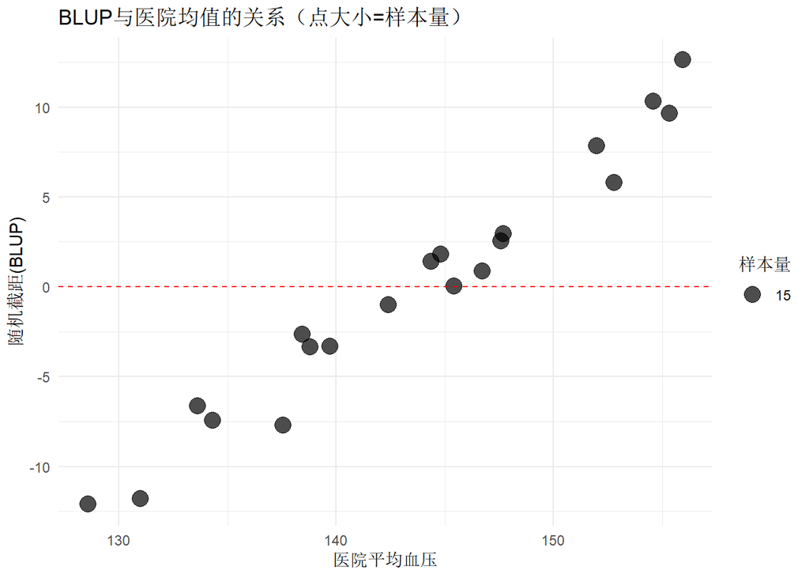

```r
# 提取BLUP
blup_values <- lme4::ranef(model_ri)$hospital
colnames(blup_values) <- "random_intercept"

# 合并医院信息
hospital_blup <- data.frame(
  hospital = rownames(blup_values),
  random_intercept = blup_values$random_intercept
)

# 计算每个医院的观测数和均值
hospital_stats <- bp_data %>%
  dplyr::group_by(hospital) %>%
  dplyr::summarise(
    n = dplyr::n(),
    mean_bp = mean(bp),
    .groups = "drop"
  )

# 合并
hospital_blup$hospital <- factor(hospital_blup$hospital)
hospital_stats$hospital <- factor(hospital_stats$hospital)
hospital_combined <- dplyr::left_join(hospital_stats, hospital_blup, by = "hospital")

# 可视化收缩效应
ggplot2::ggplot(hospital_combined, ggplot2::aes(x = mean_bp, y = random_intercept, size = n)) +
  ggplot2::geom_point(alpha = 0.7) +
  ggplot2::geom_hline(yintercept = 0, linetype = "dashed", color = "red") +
  ggplot2::labs(title = "BLUP与医院均值的关系（点大小=样本量）",
                x = "医院平均血压", y = "随机截距(BLUP)", size = "样本量") +
  ggplot2::theme_minimal()
```

```r
# 条件预测 vs 边际预测
bp_data$pred_marginal <- predict(model_ri, re.form = NA)  # 边际预测（不含随机效应）
bp_data$pred_conditional <- predict(model_ri)              # 条件预测（含随机效应）

# 比较两种预测
cat("\n========== 预测比较 ==========\n")
```

```
##
## ========== 预测比较 ==========
```

```r
cat(sprintf("边际预测RMSE: %.2f\n", sqrt(mean((bp_data$bp - bp_data$pred_marginal)^2))))
```

```
## 边际预测RMSE: 12.29
```

```r
cat(sprintf("条件预测RMSE: %.2f\n", sqrt(mean((bp_data$bp - bp_data$pred_conditional)^2))))
```

```
## 条件预测RMSE: 9.61
```

## 3.8 重复测量数据分析

### 意义与使用场景

**核心意义**：重复测量数据分析用于处理同一受试者在多个时间点的测量数据，正确处理测量值间的相关性。

**举例**：临床试验中研究治疗对血压的长期影响

**为什么这种数据适合用重复测量分析方法？**

首先，同一患者的多次血压测量不独立：相邻时间点的测量值相关性较高，间隔较远的测量值相关性较低。其次，传统方法（如每个时间点单独分析）忽略了测量值间的相关性，会导致标准误估计错误、假阳性增加。重复测量分析方法能够正确建模时间相关性，同时分析所有时间点的数据，提高统计效率。

**研究目的是什么？**

本研究有三个层次的目的：1. 估计治疗效果：判断治疗组与对照组血压变化轨迹的差异；2. 分析时间趋势：判断血压是否随时间变化，变化趋势如何；3. 检验交互效应：判断治疗效果是否随时间变化（时间×治疗交互）。

**可能得到什么样的结果？**

假设重复测量分析显示：治疗组系数=5（p<0.001），时间×治疗交互=2（p=0.01），AR(1)相关系数ρ=0.6。

1. 治疗效应：治疗组比对照组血压平均低5 mmHg。
2. 时间趋势：对照组血压随时间无显著变化；治疗组血压随时间下降更快。
3. 交互效应：时间×治疗交互显著，说明治疗效果随时间增强：第1周降低5 mmHg，第4周降低11 mmHg。
4. 相关结构：AR(1)相关系数ρ=0.6，相邻时间点测量值相关性为0.6，间隔1个时间点相关性为0.36。

**需要注意什么？**

重复测量数据需要选择合适的相关结构：复合对称（CS）假设任意两时点相关相同，适用于随机效应模型；AR(1)假设相关性随时间衰减，适用于时间序列数据；无结构（UN）最灵活但参数最多。模型选择可通过AIC比较。此外，缺失数据在重复测量中常见，需考虑缺失机制（完全随机缺失、随机缺失、非随机缺失）选择合适的处理方法。

### 数学基础

**重复测量数据的特点**：

同一受试者在不同时间点的多次测量，测量值之间存在相关性。

**常用相关结构**：

| 结构 | 特点 | 参数数量 |
| --- | --- | --- |
| 复合对称（CS） | 任意两时点相关相同 | 2 |
| 一阶自回归（AR(1)） | 相关性随时间衰减 | 2 |
| 无结构（UN） | 任意相关矩阵 | $t(t+1)/2$ |

### 代码实现

```r
# 模拟重复测量数据
set.seed(222)
n_subjects_rm <- 50
n_timepoints <- 4

subject_rm <- factor(rep(1:n_subjects_rm, each = n_timepoints))
time_rm <- rep(1:n_timepoints, n_subjects_rm)
treatment_rm <- factor(rep(rbinom(n_subjects_rm, 1, 0.5), each = n_timepoints),
                       levels = c(0, 1), labels = c("对照", "治疗"))

# 生成相关误差（AR(1)结构）
rho <- 0.6
sigma <- 5
# 创建AR(1)协方差矩阵
ar1_cov <- sigma^2 * rho^abs(outer(1:n_timepoints, 1:n_timepoints, "-"))
# 生成误差
library(MASS)
errors <- MASS::mvrnorm(n_subjects_rm, mu = rep(0, n_timepoints), Sigma = ar1_cov)
errors_vec <- as.vector(t(errors))

# 生成结果
outcome_rm <- 100 + 2 * time_rm + 5 * (treatment_rm == "治疗") * (time_rm - 1) + errors_vec

rm_data <- data.frame(
  subject = subject_rm,
  time = time_rm,
  treatment = treatment_rm,
  outcome = outcome_rm
)

# 使用nlme包拟合不同相关结构
# 复合对称
model_cs <- nlme::lme(outcome ~ time + treatment + time:treatment,
                       random = ~ 1 | subject,
                       correlation = nlme::corCompSymm(form = ~ time | subject),
                       data = rm_data,
                       method = "REML")

# AR(1)结构
model_ar1 <- nlme::lme(outcome ~ time + treatment + time:treatment,
                        random = ~ 1 | subject,
                        correlation = nlme::corAR1(form = ~ time | subject),
                        data = rm_data,
                        method = "REML")

# 无结构
model_un <- nlme::lme(outcome ~ time + treatment + time:treatment,
                       random = ~ 1 | subject,
                       correlation = nlme::corSymm(form = ~ time | subject),
                       data = rm_data,
                       method = "REML")

# 比较模型
cat("========== 相关结构比较 ==========\n")
```

```
## ========== 相关结构比较 ==========
```

```r
cat(sprintf("复合对称 AIC: %.2f\n", AIC(model_cs)))
```

```
## 复合对称 AIC: 1164.38
```

```r
cat(sprintf("AR(1) AIC: %.2f\n", AIC(model_ar1)))
```

```
## AR(1) AIC: 1150.56
```

```r
cat(sprintf("无结构 AIC: %.2f\n", AIC(model_un)))
```

```
## 无结构 AIC: 1159.23
```

```r
# 查看最优模型结果
summary(model_ar1)
```

```
## Linear mixed-effects model fit by REML
##   Data: rm_data
##        AIC      BIC    logLik
##   1150.563 1173.509 -568.2813
##
## Random effects:
##  Formula: ~1 | subject
##         (Intercept) Residual
## StdDev:     1.80747 4.592091
##
## Correlation Structure: AR(1)
##  Formula: ~time | subject
##  Parameter estimate(s):
##       Phi
## 0.5204014
## Fixed effects:  outcome ~ time + treatment + time:treatment
##                       Value Std.Error  DF  t-value p-value
## (Intercept)        99.25632 1.2774438 148 77.69917  0.0000
## time                2.31208 0.4087652 148  5.65626  0.0000
## treatment治疗      -3.52548 1.7714958  48 -1.99011  0.0523
## time:treatment治疗  4.21846 0.5668553 148  7.44186  0.0000
##  Correlation:
```

```
##                    (Intr) time   trtm治疗
## time               -0.800
## treatment治疗      -0.721  0.577
## time:treatment治疗  0.577 -0.721 -0.800
##
## Standardized Within-Group Residuals:
##         Min          Q1         Med          Q3         Max
## -2.30476044 -0.61333806 -0.05456872  0.61758569  2.40003383
##
## Number of Observations: 200
## Number of Groups: 50
```

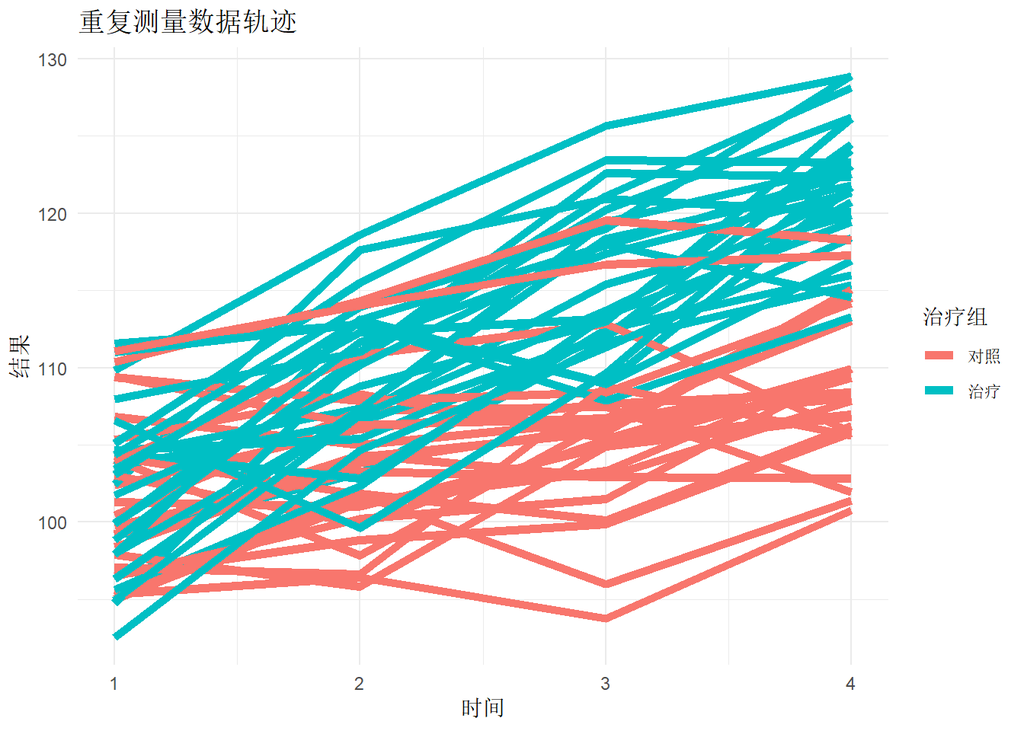

```r
# 可视化轨迹
ggplot2::ggplot(rm_data, ggplot2::aes(x = time, y = outcome, group = subject, color = treatment)) +
  ggplot2::geom_line(alpha = 0.3) +
  ggplot2::stat_summary(fun = mean, geom = "line", linewidth = 2) +
  ggplot2::labs(title = "重复测量数据轨迹", x = "时间", y = "结果", color = "治疗组") +
  ggplot2::theme_minimal()
```

## 第三章小结

### 核心知识点总结

| 主题 | 核心内容 | 关键函数 |
| --- | --- | --- |
| 随机截距 | 组间截距差异 | `lmer(... + (1\|group))` |
| 随机斜率 | 组间斜率差异 | `lmer(... + (1+x\|group))` |
| 嵌套设计 | 多层次嵌套 | `lmer(... + (1\|A/B))` |
| 交叉设计 | 因素交叉 | `lmer(... + (1\|A) + (1\|B))` |
| GLMM | 非正态混合模型 | `glmer(family = ...)` |
| BLUP | 随机效应预测 | `ranef()` |
| 重复测量 | 相关结构建模 | `nlme::lme(correlation = ...)` |

# 第四章：时间序列分析

时间序列分析用于研究随时间变化的数据，广泛应用于医学监测、疾病流行趋势分析等领域。本章将系统讲解时间序列的基本概念、平稳性检验、ARIMA模型等内容。

## 4.1 时间序列分解

### 意义与使用场景

**核心意义**：时间序列分解将数据分解为趋势、季节和随机成分，帮助理解数据的基本结构和变化规律。

**举例**：分析医院月度门诊量的长期趋势和季节波动

**为什么这种数据适合用时间序列分解？**

首先，门诊量数据随时间变化，包含多种成分：长期趋势（医院发展、人口增长）、季节波动（冬季呼吸道疾病高发）、随机扰动（突发事件）。其次，直接观察原始数据难以识别各成分的贡献。时间序列分解能够将数据拆解为趋势、季节、随机三部分，帮助理解数据结构，为预测建模提供基础。

**研究目的是什么？**

本研究有三个层次的目的：1. 识别长期趋势：判断门诊量是否呈上升或下降趋势，趋势是线性还是非线性；2. 分析季节模式：识别门诊量的季节波动规律，哪些月份高峰、哪些月份低谷；3. 评估随机波动：判断随机成分的大小，评估预测的不确定性。

**可能得到什么样的结果？**

假设分解结果显示：趋势成分从1000增长到1600（年均增长5%），季节成分在1月最高（+80）、8月最低（-60）。

1. 长期趋势：门诊量呈上升趋势，10年间增长60%，年均增长5%。
2. 季节模式：冬季（12-2月）为高峰期，夏季（7-8月）为低谷期，符合呼吸道疾病流行规律。
3. 随机波动：残差标准差为30，占均值的2%，波动较小。
4. 预测启示：预测时需考虑趋势增长和季节波动，可使用乘法模型或加法模型。

**需要注意什么？**

分解方法的选择：加法模型适用于季节波动幅度不随趋势变化的情况；乘法模型适用于季节波动幅度随趋势增大的情况。STL分解比经典分解更稳健，能够处理季节效应随时间变化的情况。此外，分解结果依赖于季节周期的设定，需确保周期设置正确。

### 数学基础

**时间序列的组成**：

$$Y_t = T_t + S_t + R_t \quad
\text{（加法模型）}$$
$$Y_t = T_t
\times S_t \times R_t \quad \text{（乘法模型）}$$

**参数说明**： - $T_t$：趋势成分（Trend） - $S_t$：季节成分（Seasonal） - $R_t$：随机/残差成分（Random/Residual）

**分解方法**：

| 方法 | 特点 |
| --- | --- |
| 经典分解 | 简单直观，假设季节效应恒定 |
| STL分解 | 季节效应可变，稳健性强 |
| X-11/X-13 | 官方统计常用 |

### 代码实现

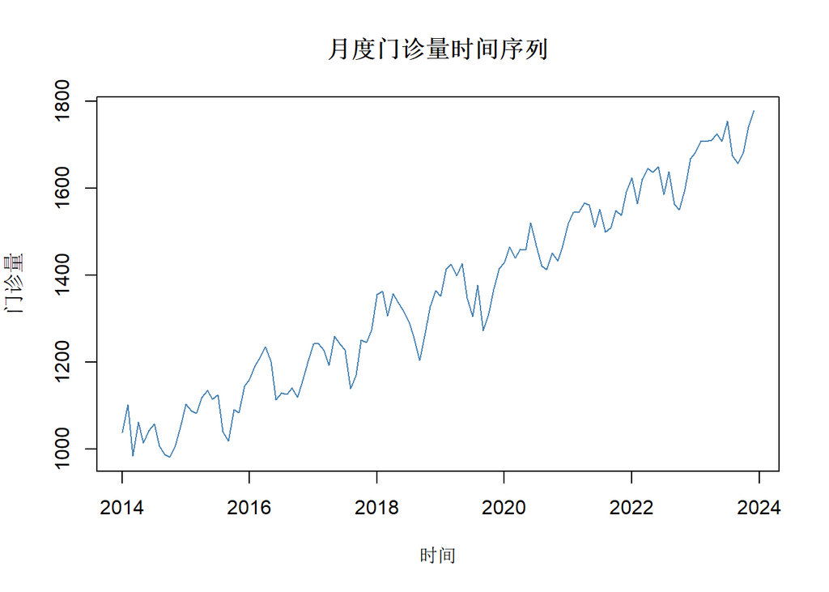

```r
# 模拟月度门诊量数据（含趋势和季节性）
set.seed(333)
n_months <- 120  # 10年的月度数据

# 趋势成分
trend <- 1000 + 5 * (1:n_months) + 0.1 * (1:n_months)^2 / 10

# 季节成分（12个月周期）
seasonal <- 50 * sin(2 * pi * (1:n_months) / 12) +
            20 * cos(4 * pi * (1:n_months) / 12)

# 随机成分
random <- rnorm(n_months, 0, 30)

# 合成时间序列
ts_data <- ts(trend + seasonal + random, frequency = 12, start = c(2014, 1))

# 绘制时间序列图
plot(ts_data, main = "月度门诊量时间序列", ylab = "门诊量", xlab = "时间", col = "steelblue")
```

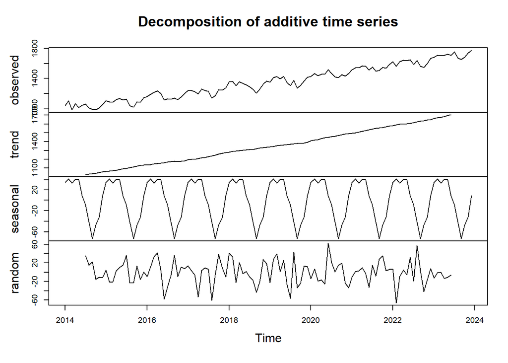

```r
# 经典分解
decomp_classic <- decompose(ts_data, type = "additive")
plot(decomp_classic)
```

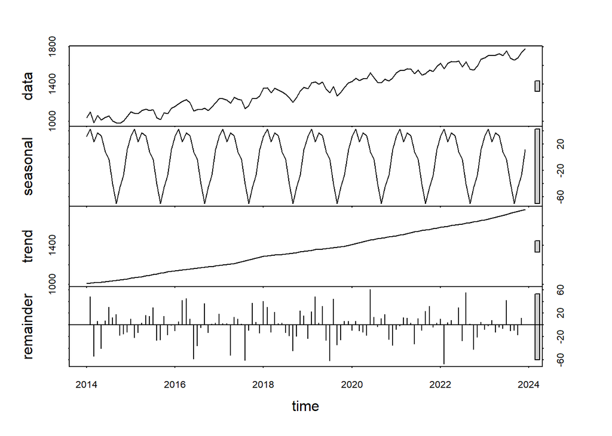

```r
# STL分解（更稳健）
decomp_stl <- stl(ts_data, s.window = "periodic")
plot(decomp_stl)
```

```r
# 提取各成分
trend_comp <- decomp_stl$time.series[, "trend"]
seasonal_comp <- decomp_stl$time.series[, "seasonal"]
random_comp <- decomp_stl$time.series[, "remainder"]

# 查看季节效应
cat("========== 季节效应摘要 ==========\n")
```

```
## ========== 季节效应摘要 ==========
```

```r
seasonal_summary <- tapply(as.numeric(seasonal_comp),
                           cycle(ts_data), mean)
print(round(seasonal_summary, 2))
```

```
##      1      2      3      4      5      6      7      8      9     10     11
##  31.59  42.60  23.05  37.02  32.08   8.41  -3.36 -40.52 -70.17 -45.41 -27.21
##     12
##  11.92
```

## 4.2 平稳性概念与检验

### 意义与使用场景

**核心意义**：平稳性是时间序列建模的基本假设，非平稳数据可能导致虚假回归。

**举例**：检验疾病发病率序列是否平稳，为ARIMA建模做准备

**为什么这种数据适合用平稳性检验？**

首先，许多时间序列模型（如ARIMA）假设数据平稳，即均值、方差不随时间变化，自相关结构稳定。其次，医疗数据中的发病率、门诊量等往往存在趋势（非平稳），直接建模可能导致虚假回归。平稳性检验能够判断数据是否满足建模假设，指导差分等预处理步骤。

**研究目的是什么？**

本研究有三个层次的目的：1. 检验平稳性：判断发病率序列是否存在趋势或单位根；2. 确定差分阶数：若非平稳，确定需要几阶差分使其平稳；3. 避免虚假回归：确保建模结果的可靠性。

**可能得到什么样的结果？**

假设平稳性检验显示：原始序列ADF检验p值=0.45（非平稳），一阶差分后ADF检验p值=0.01（平稳）。

1. 原始序列：ADF检验p值>0.05，不能拒绝非平稳假设，序列存在趋势。
2. 一阶差分：ADF检验p值<0.05，拒绝非平稳假设，差分后序列平稳。
3. 差分阶数：需要一阶差分（d=1）使序列平稳，ARIMA模型中d=1。
4. KPSS验证：KPSS检验p值<0.05（原始序列），与ADF结果一致。

**需要注意什么？**

ADF检验和KPSS检验的原假设相反：ADF原假设为非平稳，KPSS原假设为平稳。建议同时使用两种检验，结果一致时结论更可靠。若检验结果矛盾，需结合图形观察判断。此外，ADF检验对滞后阶数敏感，需选择合适的滞后阶数（通常使用AIC或BIC准则）。

### 数学基础

**严平稳（Strictly Stationary）**：

时间序列的联合分布不随时间平移而改变。

**弱平稳（Weakly Stationary）**：

满足以下条件： 1. $E(Y_t) = \mu$（常数均值） 2. $Var(Y_t) = \sigma^2$（常数方差） 3. $Cov(Y_t, Y_{t+k}) = \gamma_k$（自协方差仅依赖于滞后阶数$k$）

**单位根检验**：

**ADF检验（Augmented Dickey-Fuller）**：
$$H_0: \text{存在单位根（非平稳）}$$
$$H_1: \text{不存在单位根（平稳）}$$

**KPSS检验**：
$$H_0:
\text{平稳}$$
$$H_1:
\text{非平稳}$$

### 代码实现

```r
# 检验平稳性
library(tseries)
library(forecast)

# ADF检验
adf_test <- tseries::adf.test(ts_data)
cat("========== ADF检验 ==========\n")
```

```
## ========== ADF检验 ==========
```

```r
print(adf_test)
```

```
##
##  Augmented Dickey-Fuller Test
##
## data:  ts_data
## Dickey-Fuller = -6.6307, Lag order = 4, p-value = 0.01
## alternative hypothesis: stationary
```

```r
# KPSS检验
kpss_test <- tseries::kpss.test(ts_data)
cat("\n========== KPSS检验 ==========\n")
```

```
##
## ========== KPSS检验 ==========
```

```r
print(kpss_test)
```

```
##
##  KPSS Test for Level Stationarity
##
## data:  ts_data
## KPSS Level = 2.4427, Truncation lag parameter = 4, p-value = 0.01
```

```r
# PP检验（Phillips-Perron）
pp_test <- tseries::pp.test(ts_data)
cat("\n========== PP检验 ==========\n")
```

```
##
## ========== PP检验 ==========
```

```r
print(pp_test)
```

```
##
##  Phillips-Perron Unit Root Test
##
## data:  ts_data
## Dickey-Fuller Z(alpha) = -51.614, Truncation lag parameter = 4, p-value
## = 0.01
## alternative hypothesis: stationary
```

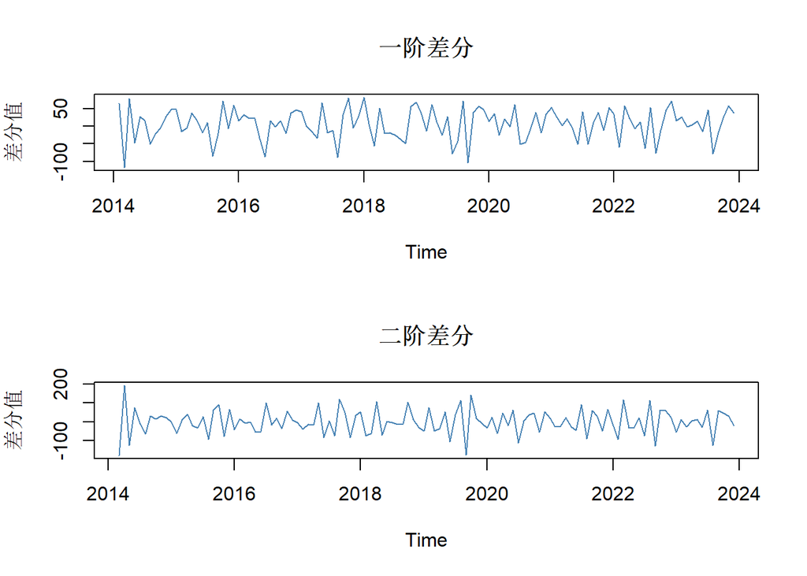

```r
# 差分使其平稳
ts_diff <- diff(ts_data)
ts_diff2 <- diff(ts_diff)

# 绘制差分后的序列
par(mfrow = c(2, 1))
plot(ts_diff, main = "一阶差分", ylab = "差分值", col = "steelblue")
plot(ts_diff2, main = "二阶差分", ylab = "差分值", col = "steelblue")
```

```r
par(mfrow = c(1, 1))

# 检验差分后的平稳性
adf_diff <- tseries::adf.test(ts_diff2)
cat("\n========== 差分后ADF检验 ==========\n")
```

```
##
## ========== 差分后ADF检验 ==========
```

```r
print(adf_diff)
```

```
##
##  Augmented Dickey-Fuller Test
##
## data:  ts_diff2
## Dickey-Fuller = -7.4167, Lag order = 4, p-value = 0.01
## alternative hypothesis: stationary
```

## 4.3 自相关与偏自相关

### 意义与使用场景

**核心意义**：ACF和PACF是识别时间序列模型阶数的关键工具，帮助确定ARIMA模型的参数。

**举例**：分析传染病发病数据的自相关结构，确定ARIMA模型阶数

**为什么这种数据适合用自相关分析？**

首先，时间序列数据的特点是相邻观测之间存在相关性：本周发病人数可能与上周、上上周有关。其次，不同类型的时间序列模型（AR、MA、ARMA）具有不同的自相关结构特征。ACF和PACF图形能够揭示数据的自相关模式，帮助识别模型类型和阶数。

**研究目的是什么？**

本研究有三个层次的目的：1. 识别自相关结构：判断数据是否存在显著的自相关，自相关模式如何；2. 确定模型类型：根据ACF和PACF的形态判断使用AR、MA还是ARMA模型；3. 确定模型阶数：根据ACF和PACF的截尾位置确定模型的阶数p和q。

**可能得到什么样的结果？**

假设ACF和PACF分析显示：ACF在滞后1-2阶显著后快速衰减，PACF在滞后1阶后截尾。

1. ACF形态：ACF在滞后1、2阶显著（超过置信区间），之后快速衰减至不显著。
2. PACF形态：PACF在滞后1阶显著，滞后2阶及之后不显著（截尾）。
3. 模型识别：PACF截尾→AR模型，截尾位置在滞后1阶→AR(1)模型。
4. 白噪声检验：Ljung-Box检验p值<0.001，序列非白噪声，存在可建模的自相关结构。

**需要注意什么？**

ACF和PACF的识别规则是经验性的，实际数据可能不典型。建议结合auto.arima()函数自动选择参数，并比较多种模型的AIC值。此外，季节性数据的ACF和PACF会在季节滞后处（如滞后12、24）出现峰值，需要识别季节性成分。

### 数学基础

**自相关函数（ACF）**：

$$\rho_k = \frac{\gamma_k}{\gamma_0} =
\frac{Cov(Y_t, Y_{t-k})}{Var(Y_t)}$$

**偏自相关函数（PACF）**：

控制中间所有滞后项后，$Y_t$与$Y_{t-k}$的相关系数。

$$\phi_{kk} = Corr(Y_t, Y_{t-k} | Y_{t-1},
Y_{t-2}, \ldots, Y_{t-k+1})$$

**模型识别规则**：

| 模型 | ACF | PACF |
| --- | --- | --- |
| AR(p) | 拖尾衰减 | p阶后截尾 |
| MA(q) | q阶后截尾 | 拖尾衰减 |
| ARMA(p,q) | 拖尾衰减 | 拖尾衰减 |

### 代码实现

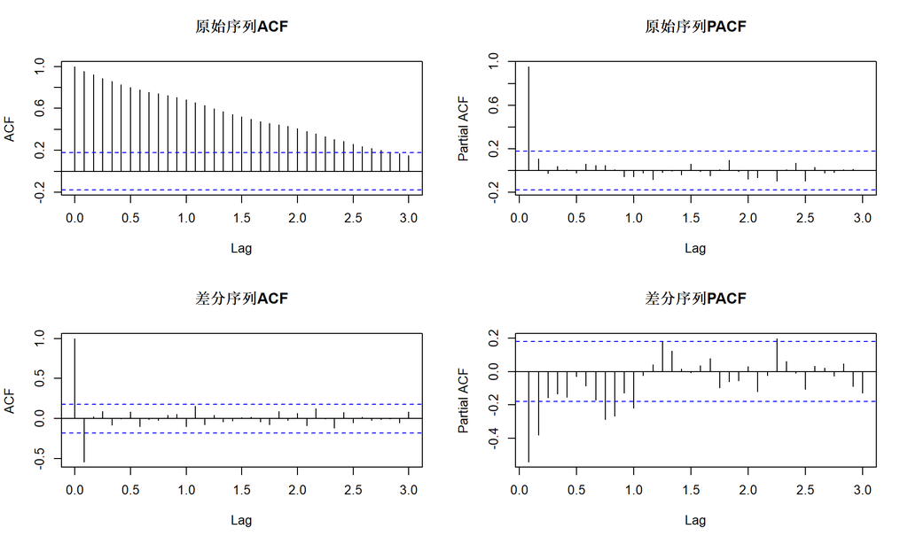

```r
# 绘制ACF和PACF
par(mfrow = c(2, 2))
acf(ts_data, main = "原始序列ACF", lag.max = 36)
pacf(ts_data, main = "原始序列PACF", lag.max = 36)
acf(ts_diff2, main = "差分序列ACF", lag.max = 36)
pacf(ts_diff2, main = "差分序列PACF", lag.max = 36)
```

```r
par(mfrow = c(1, 1))

# 白噪声检验
# Ljung-Box检验
lb_test <- Box.test(ts_data, lag = 12, type = "Ljung-Box")
cat("========== Ljung-Box检验 ==========\n")
```

```
## ========== Ljung-Box检验 ==========
```

```r
print(lb_test)
```

```
##
##  Box-Ljung test
##
## data:  ts_data
## X-squared = 1004.5, df = 12, p-value < 2.2e-16
```

```r
# 对残差进行白噪声检验
residuals_stl <- decomp_stl$time.series[, "remainder"]
lb_residuals <- Box.test(residuals_stl, lag = 12, type = "Ljung-Box")
cat("\n========== 残差白噪声检验 ==========\n")
```

```
##
## ========== 残差白噪声检验 ==========
```

```r
print(lb_residuals)
```

```
##
##  Box-Ljung test
##
## data:  residuals_stl
## X-squared = 19.598, df = 12, p-value = 0.07508
```

## 4.4 ARIMA模型

### 意义与使用场景

**核心意义**：ARIMA模型是时间序列预测的经典方法，通过自回归、差分和移动平均的组合来建模和预测。

**举例**：预测医院未来12个月的门诊量

**为什么这种数据适合用ARIMA模型？**

首先，门诊量数据是典型的时间序列，具有趋势和季节性，经差分后可达到平稳。其次，门诊量存在自相关：本月门诊量可能与上月、去年同期有关。ARIMA模型能够捕捉这种自相关结构，同时处理趋势（通过差分）和季节性（通过季节性ARIMA），是预测门诊量的经典方法。

**研究目的是什么？**

本研究有三个层次的目的：1. 建立预测模型：根据历史门诊量数据建立ARIMA模型；2. 评估模型拟合：通过残差检验判断模型是否充分捕捉了数据特征；3. 进行预测：预测未来12个月的门诊量，为医院资源配置提供依据。

**可能得到什么样的结果？**

假设ARIMA(1,1,1)(1,1,0)12模型显示：AR(1)系数=0.6，MA(1)系数=0.3，季节AR(1)系数=0.5，AIC=1250。

1. 模型结构：ARIMA(1,1,1)(1,1,0)12，包含一阶差分、季节差分和季节自回归。
2. 参数解释：AR(1)=0.6，说明当月门诊量与上月正相关；季节AR(1)=0.5，说明与去年同期正相关。
3. 模型诊断：残差Ljung-Box检验p值=0.35，残差为白噪声，模型拟合充分。
4. 预测结果：预测未来12个月门诊量呈上升趋势，95%置信区间宽度约为±150。

**需要注意什么？**

ARIMA模型的参数选择可通过ACF/PACF图形或auto.arima()函数确定。auto.arima()基于AIC准则自动选择最优参数，但结果可能与图形分析不同，建议比较多种模型。模型诊断需检验残差是否为白噪声，若残差存在自相关，说明模型未充分拟合。预测的置信区间会随预测期延长而变宽，长期预测不确定性较大。

### 数学基础

**ARIMA(p, d, q)模型**：

- **AR(p)自回归**：$Y_t = \phi_1 Y_{t-1} + \cdots + \phi_p Y_{t-p} + \varepsilon_t$
- **I(d)差分**：差分次数使序列平稳
- **MA(q)移动平均**：$Y_t = \varepsilon_t + \theta_1 \varepsilon_{t-1} + \cdots + \theta_q \varepsilon_{t-q}$

**完整形式**：
$$\phi(B)(1-B)^d Y_t =
\theta(B)\varepsilon_t$$

其中： - $\phi(B) = 1 - \phi_1 B - \cdots - \phi_p B^p$ - $\theta(B) = 1 + \theta_1 B + \cdots + \theta_q B^q$ - $B$：后移算子，$BY_t = Y_{t-1}$

### 代码实现

```r
# 自动选择ARIMA参数
library(forecast)
auto_model <- forecast::auto.arima(ts_data, seasonal = TRUE)
summary(auto_model)
```

```
## Series: ts_data
## ARIMA(1,0,1)(2,1,0)[12] with drift
##
## Coefficients:
##          ar1      ma1     sar1     sar2   drift
##       0.9775  -0.8915  -0.7732  -0.4405  6.3351
## s.e.  0.0345   0.0674   0.0899   0.0918  0.4750
##
## sigma^2 = 1132:  log likelihood = -534.93
## AIC=1081.85   AICc=1082.69   BIC=1097.95
##
## Training set error measures:
##                    ME     RMSE      MAE          MPE     MAPE      MASE
## Training set 1.263417 31.17644 22.84473 0.0002043013 1.700539 0.2957541
##                    ACF1
## Training set 0.08195347
```

```r
# 手动拟合ARIMA模型
# 基于ACF/PACF判断：p=1, d=1, q=1
model_arima <- forecast::Arima(ts_data, order = c(1, 1, 1), seasonal = c(1, 1, 0))
summary(model_arima)
```

```
## Series: ts_data
## ARIMA(1,1,1)(1,1,0)[12]
##
## Coefficients:
##          ar1      ma1     sar1
##       0.1136  -0.9481  -0.5391
## s.e.  0.1004   0.0325   0.0818
##
## sigma^2 = 1381:  log likelihood = -540.5
## AIC=1089   AICc=1089.39   BIC=1099.69
##
## Training set error measures:
##                    ME     RMSE      MAE      MPE     MAPE      MASE
## Training set 4.007443 34.60021 25.47387 0.230051 1.876509 0.3297915
##                      ACF1
## Training set 0.0006771485
```

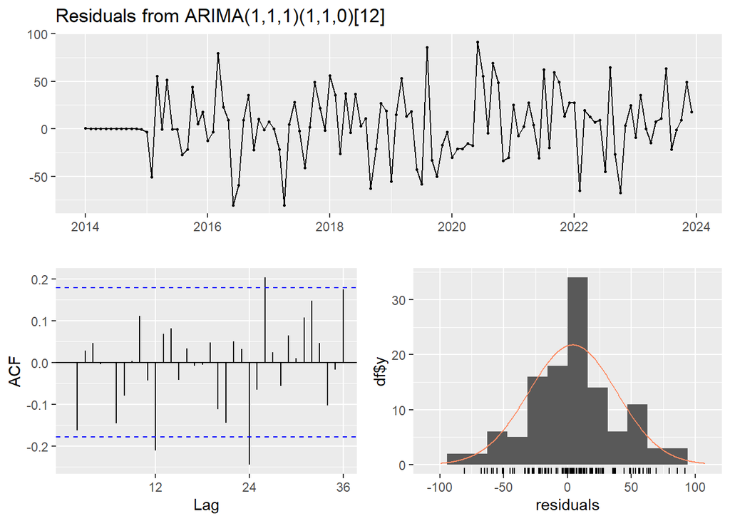

```
##
##  Ljung-Box test
##
## data:  Residuals from ARIMA(1,1,1)(1,1,0)[12]
## Q* = 32.143, df = 21, p-value = 0.05663
##
## Model df: 3.   Total lags used: 24
```

```r
# 模型诊断
# 残差检验
checkresiduals(model_arima)
```

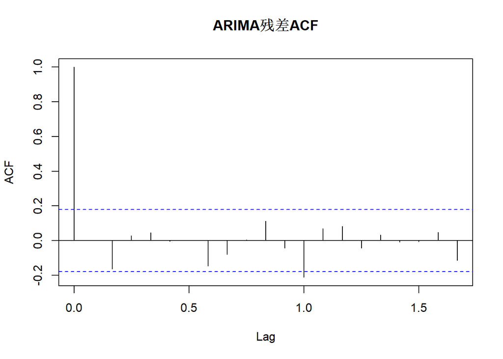

```r
# 残差ACF
acf(residuals(model_arima), main = "ARIMA残差ACF")
```

```r
# Ljung-Box检验
lb_arima <- Box.test(residuals(model_arima), lag = 12, type = "Ljung-Box", fitdf = 2)
cat("\n========== ARIMA残差检验 ==========\n")
```

```
##
## ========== ARIMA残差检验 ==========
```

```r
print(lb_arima)
```

```
##
##  Box-Ljung test
##
## data:  residuals(model_arima)
## X-squared = 15.172, df = 10, p-value = 0.1259
```

```r
# 模型比较
cat("\n========== 模型比较 ==========\n")
```

```
##
## ========== 模型比较 ==========
```

```r
cat(sprintf("自动选择ARIMA AIC: %.2f\n", AIC(auto_model)))
```

```
## 自动选择ARIMA AIC: 1081.85
```

```r
cat(sprintf("手动ARIMA AIC: %.2f\n", AIC(model_arima)))
```

```
## 手动ARIMA AIC: 1089.00
```

## 4.5 季节性ARIMA

### 意义与使用场景

**核心意义**：季节性ARIMA（SARIMA）扩展了ARIMA模型，专门处理具有季节性周期的时间序列数据。

**举例**：预测流感季节性爆发的发病人数

**为什么这种数据适合用季节性ARIMA模型？**

首先，流感发病具有明显的季节性：冬季高发，夏季低发，周期为12个月。其次，流感发病数据同时存在非季节性自相关（本周与上周相关）和季节性自相关（本周与去年同期相关）。SARIMA模型能够同时建模这两种自相关结构，是预测季节性传染病的理想方法。

**研究目的是什么？**

本研究有三个层次的目的：1. 捕捉季节模式：建模流感发病的年度周期性；2. 区分季节与非季节效应：分别估计非季节性自相关和季节性自相关的参数；3. 提高预测精度：通过季节性建模提高预测准确性。

**可能得到什么样的结果？**

假设SARIMA(1,0,1)(1,1,0)12模型显示：非季节AR(1)=0.5，非季节MA(1)=0.3，季节AR(1)=0.7。

1. 非季节效应：AR(1)=0.5，说明本周发病人数与上周正相关，存在短期持续性。
2. 季节效应：季节AR(1)=0.7，说明本周发病人数与去年同期高度相关，季节性明显。
3. 季节差分：D=1，说明需要进行季节差分（当年减去去年同期）使序列平稳。
4. 预测应用：预测显示今年冬季（12-2月）流感发病人数将比去年同期增加15%。

**需要注意什么？**

SARIMA模型的参数较多（非季节p,d,q和季节P,D,Q），需要足够长的历史数据（至少几个完整周期）来估计。季节周期s的选择应与数据的季节性一致：月度数据s=12，季度数据s=4，周数据s=52。模型选择可使用auto.arima()函数，设置seasonal=TRUE。

### 数学基础

**SARIMA(p, d, q)(P, D, Q)_s模型**：

$$\phi(B)\Phi(B^s)(1-B)^d(1-B^s)^D Y_t =
\theta(B)\Theta(B^s)\varepsilon_t$$

**参数说明**： - $(p, d, q)$：非季节部分 - $(P, D, Q)$：季节部分 - $s$：季节周期（如月度数据$s=12$）

### 代码实现

```r
# 拟合季节性ARIMA
model_sarima <- forecast::Arima(ts_data,
                                 order = c(1, 1, 1),
                                 seasonal = c(1, 1, 1))
summary(model_sarima)
```

```
## Series: ts_data
## ARIMA(1,1,1)(1,1,1)[12]
##
## Coefficients:
##          ar1      ma1     sar1     sma1
##       0.1091  -0.8836  -0.1368  -0.9271
## s.e.  0.1085   0.0545   0.1301   0.4063
##
## sigma^2 = 950.9:  log likelihood = -529.31
## AIC=1068.62   AICc=1069.21   BIC=1081.98
##
## Training set error measures:
##                    ME     RMSE      MAE       MPE     MAPE      MASE
## Training set 4.027794 28.56942 20.17855 0.2309524 1.497407 0.2612369
##                     ACF1
## Training set -0.01534729
```

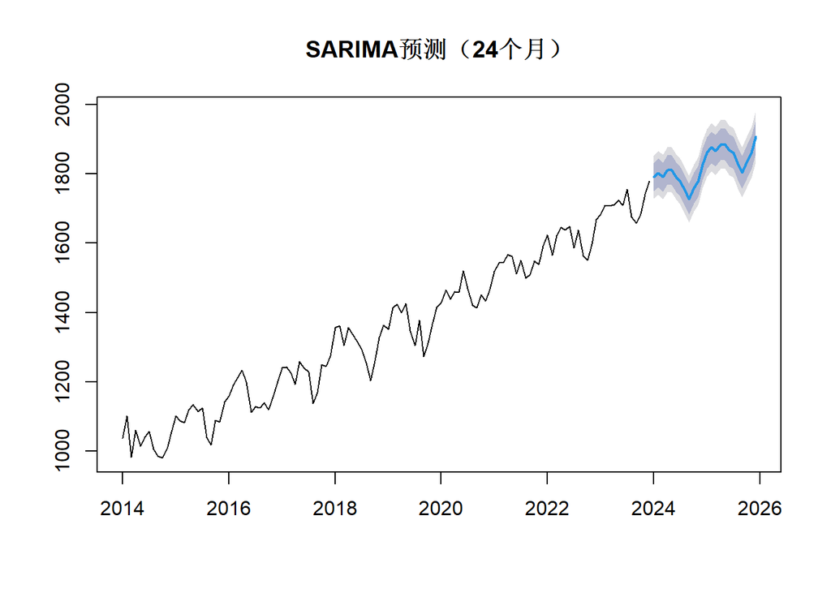

```r
# 预测
forecast_sarima <- forecast::forecast(model_sarima, h = 24)

# 绘制预测
plot(forecast_sarima, main = "SARIMA预测（24个月）")
```

```r
# 预测区间
cat("\n========== 预测值及置信区间 ==========\n")
```

```
##
## ========== 预测值及置信区间 ==========
```

```r
print(forecast_sarima)
```

```
##          Point Forecast    Lo 80    Hi 80    Lo 95    Hi 95
## Jan 2024       1790.368 1749.954 1830.782 1728.560 1852.176
## Feb 2024       1802.715 1761.288 1844.143 1739.357 1866.074
## Mar 2024       1791.031 1749.214 1832.848 1727.078 1854.985
## Apr 2024       1811.537 1769.384 1853.691 1747.069 1876.005
## May 2024       1811.204 1768.721 1853.686 1746.233 1876.175
## Jun 2024       1791.946 1749.138 1834.755 1726.477 1857.416
## Jul 2024       1776.688 1733.556 1819.819 1710.724 1842.652
## Aug 2024       1753.056 1709.604 1796.508 1686.602 1819.511
## Sep 2024       1726.941 1683.170 1770.711 1659.999 1793.882
## Oct 2024       1758.930 1714.843 1803.017 1691.505 1826.355
## Nov 2024       1779.444 1735.042 1823.845 1711.537 1847.350
## Dec 2024       1827.453 1782.734 1872.171 1759.061 1895.844
## Jan 2025       1859.944 1815.035 1904.854 1791.261 1928.628
## Feb 2025       1876.385 1831.198 1921.573 1807.277 1945.494
## Mar 2025       1866.311 1820.837 1911.786 1796.764 1935.858
## Apr 2025       1884.525 1838.765 1930.286 1814.541 1954.510
## May 2025       1886.073 1840.028 1932.118 1815.654 1956.492
## Jun 2025       1867.303 1820.976 1913.631 1796.452 1938.155
## Jul 2025       1860.492 1813.884 1907.101 1789.211 1931.774
## Aug 2025       1829.234 1782.346 1876.122 1757.525 1900.942
## Sep 2025       1804.096 1756.931 1851.261 1731.963 1876.229
## Oct 2025       1835.412 1787.971 1882.853 1762.857 1907.967
## Nov 2025       1860.927 1813.210 1908.643 1787.950 1933.903
## Dec 2025       1907.490 1859.493 1955.486 1834.086 1980.893
```

```r
# 模型准确度评估
accuracy_sarima <- forecast::accuracy(forecast_sarima)
cat("\n========== 模型准确度 ==========\n")
```

```
##
## ========== 模型准确度 ==========
```

```r
print(accuracy_sarima)
```

```
##                    ME     RMSE      MAE       MPE     MAPE      MASE
## Training set 4.027794 28.56942 20.17855 0.2309524 1.497407 0.2612369
##                     ACF1
## Training set -0.01534729
```

## 4.6 GARCH模型

### 意义与使用场景

**核心意义**：GARCH模型用于建模时间序列的波动率聚集现象，即大波动后往往跟随大波动，小波动后跟随小波动。

**举例**：分析医院急诊就诊量的异常波动

**为什么这种数据适合用GARCH模型？**

首先，急诊就诊量存在波动聚集现象：某些时期就诊量波动剧烈（如流感爆发期），某些时期波动平稳。其次，传统时间序列模型假设方差恒定，无法捕捉波动率的时变性。GARCH模型能够建模波动率的动态变化，识别高风险时期，为医院应急管理提供依据。

**研究目的是什么？**

本研究有三个层次的目的：1. 建模波动率：估计急诊就诊量波动率的动态变化规律；2. 识别高风险时期：判断哪些时期波动率异常升高，需要加强应急准备；3. 预测波动率：预测未来时期的波动率，评估风险水平。

**可能得到什么样的结果？**

假设GARCH(1,1)模型显示：α=0.3（ARCH系数），β=0.6（GARCH系数），α+β=0.9。

1. 波动持续性：α+β=0.9，接近1，说明波动率具有高度持续性，大波动后会持续一段时间。
2. 冲击影响：α=0.3，说明突发事件（如流感爆发）对波动率的影响较大。
3. 波动率预测：当前波动率为50人次/天，预测下周波动率为45人次/天。
4. 高风险识别：12月-2月波动率显著高于其他月份，与流感季节一致。

**需要注意什么？**

GARCH模型假设收益率（或波动）均值为零或已建模，适用于建模条件方差。在医疗数据中，需先对原始数据建模均值（如用ARIMA），再对残差建模波动率。GARCH模型的参数需满足约束条件：α+β<1保证平稳性，α>0，β>0。模型选择可通过AIC比较不同阶数的GARCH模型。

### 数学基础

**ARCH模型**：

自回归条件异方差模型，用于建模波动率聚集。

$$\sigma_t^2 = \alpha_0 + \alpha_1
\varepsilon_{t-1}^2 + \cdots + \alpha_q \varepsilon_{t-q}^2$$

**GARCH(p, q)模型**：

$$\sigma_t^2 = \alpha_0 + \sum_{i=1}^{q}
\alpha_i \varepsilon_{t-i}^2 + \sum_{j=1}^{p} \beta_j
\sigma_{t-j}^2$$

**参数说明**： - $\alpha_i$：ARCH系数（冲击的影响） - $\beta_j$：GARCH系数（波动的持续性）

### 代码实现

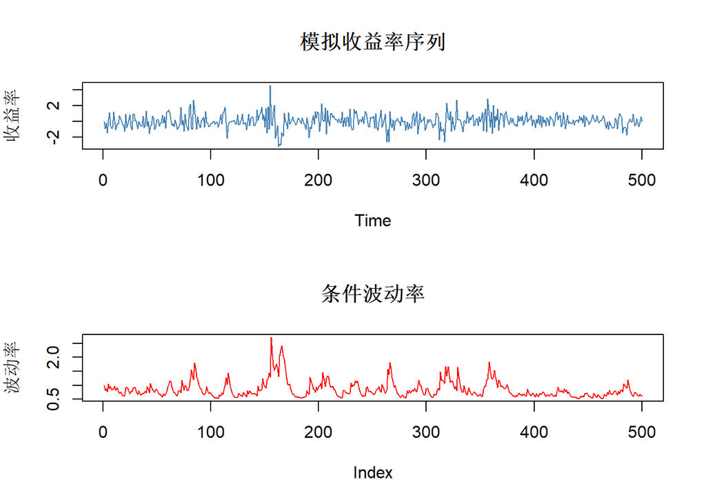

```r
# 模拟金融收益率数据（含波动聚集）
set.seed(444)
n_garch <- 500

# GARCH(1,1)参数
omega <- 0.1
alpha <- 0.3
beta <- 0.6

# 生成GARCH过程
returns <- numeric(n_garch)
sigma2 <- numeric(n_garch)
sigma2[1] <- omega / (1 - alpha - beta)

for (t in 2:n_garch) {
  returns[t] <- rnorm(1, 0, sqrt(sigma2[t-1]))
  sigma2[t] <- omega + alpha * returns[t-1]^2 + beta * sigma2[t-1]
}

# 创建时间序列
ts_garch <- ts(returns)

# 绘制收益率和波动率
par(mfrow = c(2, 1))
plot(ts_garch, main = "模拟收益率序列", ylab = "收益率", col = "steelblue")
plot(sqrt(sigma2), type = "l", main = "条件波动率", ylab = "波动率", col = "red")
```

```r
par(mfrow = c(1, 1))

# 拟合GARCH模型
library(tseries)
library(fGarch)

model_garch <- fGarch::garchFit(~ garch(1, 1), data = ts_garch, trace = FALSE)
summary(model_garch)
```

```
##
## Title:
##  GARCH Modelling
##
## Call:
##  fGarch::garchFit(formula = ~garch(1, 1), data = ts_garch, trace = FALSE)
##
## Mean and Variance Equation:
##  data ~ garch(1, 1)
## <environment: 0x00000143597bb690>
##  [data = ts_garch]
##
## Conditional Distribution:
##  norm
##
## Coefficient(s):
##       mu     omega    alpha1     beta1
## 0.036302  0.079514  0.285839  0.626649
##
## Std. Errors:
##  based on Hessian
##
## Error Analysis:
##         Estimate  Std. Error  t value Pr(>|t|)
## mu       0.03630     0.03068    1.183  0.23675
## omega    0.07951     0.02490    3.193  0.00141 **
## alpha1   0.28584     0.06191    4.617 3.89e-06 ***
## beta1    0.62665     0.06185   10.131  < 2e-16 ***
## ---
## Signif. codes:  0 '***' 0.001 '**' 0.01 '*' 0.05 '.' 0.1 ' ' 1
##
## Log Likelihood:
##  -599.4667    normalized:  -1.198933
##
## Description:
##  Sun Mar 29 19:35:05 2026 by user: XTS-green
##
##
##
## Standardised Residuals Tests:
##                                  Statistic   p-Value
##  Jarque-Bera Test   R    Chi^2   2.9667297 0.2268730
##  Shapiro-Wilk Test  R    W       0.9953873 0.1454590
##  Ljung-Box Test     R    Q(10)  11.3868843 0.3281808
##  Ljung-Box Test     R    Q(15)  13.3614908 0.5743983
##  Ljung-Box Test     R    Q(20)  22.1278027 0.3336162
##  Ljung-Box Test     R^2  Q(10)  12.8928778 0.2297230
##  Ljung-Box Test     R^2  Q(15)  19.0386900 0.2119860
##  Ljung-Box Test     R^2  Q(20)  23.8860054 0.2474072
##  LM Arch Test       R    TR^2   13.0391041 0.3662049
##
## Information Criterion Statistics:
##      AIC      BIC      SIC     HQIC
## 2.413867 2.447584 2.413740 2.427097
```

```r
# 提取参数
cat("\n========== GARCH参数估计 ==========\n")
```

```
##
## ========== GARCH参数估计 ==========
```

```r
cat(sprintf("omega = %.4f\n", model_garch@fit$par["omega"]))
```

```
## omega = 0.0795
```

```r
cat(sprintf("alpha1 = %.4f\n", model_garch@fit$par["alpha1"]))
```

```
## alpha1 = 0.2858
```

```r
cat(sprintf("beta1 = %.4f\n", model_garch@fit$par["beta1"]))
```

```
## beta1 = 0.6266
```

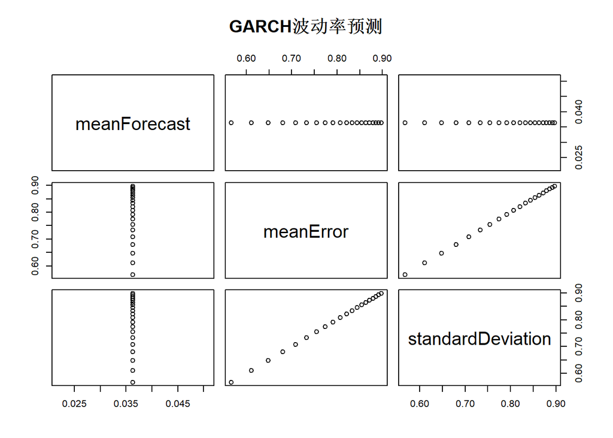

```r
# 波动率预测
pred_garch <- predict(model_garch, n.ahead = 20)
plot(pred_garch, main = "GARCH波动率预测")
```

## 第四章小结

### 核心知识点总结

| 主题 | 核心内容 | 关键函数 |
| --- | --- | --- |
| 时间序列分解 | 趋势、季节、随机 | `decompose()`, `stl()` |
| 平稳性检验 | ADF、KPSS检验 | `adf.test()`, `kpss.test()` |
| ACF/PACF | 模型识别工具 | `acf()`, `pacf()` |
| ARIMA | 自回归移动平均 | `Arima()`, `auto.arima()` |
| SARIMA | 季节性ARIMA | `Arima(seasonal = ...)` |
| GARCH | 条件异方差 | `garchFit()` |

# 第五章：生存分析

生存分析是研究事件发生时间的统计分析方法，广泛应用于医学研究中的生存时间、疾病复发时间等分析。本章将系统讲解生存函数、Cox比例风险模型等核心内容。

## 5.1 生存函数与风险函数

### 意义与使用场景

**核心意义**：生存函数描述生存时间超过某时刻的概率，风险函数描述瞬时事件发生风险，两者是生存分析的基础概念。

**举例**：研究癌症患者的生存时间及影响因素

**为什么这种数据适合用生存分析？**

首先，研究终点是”死亡时间”，是典型的时间到事件数据。其次，研究结束时部分患者仍存活（删失数据），传统方法无法正确处理。生存分析能够利用删失数据的信息，正确估计生存概率和风险函数，是分析这类数据的理想方法。

**研究目的是什么？**

本研究有三个层次的目的：1. 描述生存模式：估计生存函数，判断生存概率随时间的变化规律；2. 评估风险水平：计算风险函数，判断不同时期的死亡风险；3. 识别影响因素：分析哪些因素影响生存时间。

**可能得到什么样的结果？**

假设生存分析显示：1年生存率=85%，3年生存率=60%，5年生存率=45%，中位生存时间=4.2年。

1. 生存函数：生存概率随时间递减，前2年下降较慢，2年后下降加快。
2. 风险函数：风险随时间增加，第1年风险较低，第3-5年风险较高。
3. 删失比例：研究结束时35%的患者仍存活（删失），生存分析能够利用这部分信息。
4. 临床意义：早期生存率较高，提示早期干预的重要性。

**需要注意什么？**

生存分析的核心是正确处理删失数据。删失分为右删失（只知道生存时间大于某值）、左删失（只知道生存时间小于某值）、区间删失（只知道生存时间在某区间内）。最常见的右删失需满足非信息性删失假设：删失原因与生存时间无关。

### 数学基础

**生存函数（Survival Function）**：

$$S(t) = P(T > t) = 1 -
F(t)$$

表示生存时间超过$t$的概率。

**风险函数（Hazard Function）**：

$$h(t) = \lim_{\Delta t \to 0} \frac{P(t
\leq T < t + \Delta t | T \geq t)}{\Delta t} =
\frac{f(t)}{S(t)}$$

表示在时刻$t$瞬时发生事件的风险。

**累积风险函数**：

$$H(t) = \int_0^t h(u) du = -\log
S(t)$$

**关键关系**：
$$S(t) =
\exp\left(-\int_0^t h(u) du\right) = \exp(-H(t))$$

### 代码实现

```r
# 模拟生存数据
set.seed(555)
n_surv <- 200

# 生成协变量
age_surv <- round(rnorm(n_surv, 60, 10))
treatment_surv <- rbinom(n_surv, 1, 0.5)
stage_surv <- sample(1:3, n_surv, replace = TRUE)  # 疾病分期

# 生成生存时间（Weibull分布）
# 基线风险随年龄和分期增加
lambda <- 0.01 * exp(0.02 * age_surv + 0.5 * stage_surv - 0.5 * treatment_surv)
shape <- 1.5
surv_time <- rweibull(n_surv, shape = shape, scale = lambda^(-1/shape))

# 生成删失时间
censor_time <- runif(n_surv, min = 0, max = 10)
observed_time <- pmin(surv_time, censor_time)
status <- as.numeric(surv_time <= censor_time)  # 1=事件发生，0=删失

# 创建数据框
surv_data <- data.frame(
  patient_id = 1:n_surv,
  age = age_surv,
  treatment = factor(treatment_surv, levels = c(0, 1), labels = c("对照", "治疗")),
  stage = factor(stage_surv, levels = 1:3, labels = c("I期", "II期", "III期")),
  time = observed_time,
  status = status
)

# 查看数据
str(surv_data)
```

```
## 'data.frame':    200 obs. of  6 variables:
##  $ patient_id: int  1 2 3 4 5 6 7 8 9 10 ...
##  $ age       : num  57 65 64 79 42 69 58 74 60 66 ...
##  $ treatment : Factor w/ 2 levels "对照","治疗": 2 2 1 2 1 1 1 1 1 2 ...
##  $ stage     : Factor w/ 3 levels "I期","II期","III期": 3 3 1 1 2 2 1 1 2 3 ...
##  $ time      : num  0.994 1.695 2.111 3.537 0.721 ...
##  $ status    : num  0 1 0 0 0 1 1 1 1 0 ...
```

```r
cat("\n========== 删失情况 ==========\n")
```

```
##
## ========== 删失情况 ==========
```

```r
cat(sprintf("事件发生: %d (%.1f%%)\n", sum(status), mean(status) * 100))
```

```
## 事件发生: 102 (51.0%)
```

```r
cat(sprintf("删失: %d (%.1f%%)\n", sum(1-status), mean(1-status) * 100))
```

```
## 删失: 98 (49.0%)
```

## 5.2 Kaplan-Meier估计

### 意义与使用场景

**核心意义**：Kaplan-Meier估计是非参数方法，用于估计生存函数，能够处理删失数据。

**举例**：比较不同治疗组的生存曲线

**为什么这种数据适合用Kaplan-Meier估计？**

首先，我们需要估计各组的生存概率随时间的变化，但数据中存在删失（研究结束时部分患者仍存活）。其次，我们不想假设生存时间服从特定分布（如指数分布、Weibull分布）。Kaplan-Meier估计是非参数方法，无需分布假设，能够正确处理删失数据，直观展示生存曲线。

**研究目的是什么？**

本研究有三个层次的目的：1. 估计生存曲线：绘制各组的生存概率随时间变化的曲线；2. 计算中位生存时间：估计各组生存时间的中位数；3. 比较组间差异：初步判断不同治疗组的生存情况是否存在差异。

**可能得到什么样的结果？**

假设Kaplan-Meier估计显示：治疗组中位生存时间=5.2年，对照组中位生存时间=3.8年。

1. 生存曲线：治疗组的生存曲线始终位于对照组上方，提示治疗组生存情况更好。
2. 中位生存时间：治疗组中位生存时间比对照组延长1.4年（37%）。
3. 生存率比较：治疗组1年生存率=90%，对照组1年生存率=75%；治疗组5年生存率=55%，对照组5年生存率=35%。
4. 风险表：随时间推移，风险集中人数逐渐减少，需要关注曲线尾部的可靠性。

**需要注意什么？**

Kaplan-Meier估计的可靠性依赖于风险集中的样本量。当风险集中人数较少时（如曲线尾部），估计的标准误较大，置信区间较宽。此外，Kaplan-Meier曲线只能描述生存情况，不能直接判断组间差异是否显著，需要配合对数秩检验使用。

### 数学基础

**Kaplan-Meier估计量**：

$$\hat{S}(t) = \prod_{t_i \leq t} \left(1
- \frac{d_i}{n_i}\right)$$

**参数说明**： - $t_i$：事件发生时间点 - $d_i$：在$t_i$时刻发生事件的个体数 - $n_i$：在$t_i$时刻前仍在风险集中的个体数

**标准误（Greenwood公式）**：
$$SE(\hat{S}(t)) = \hat{S}(t) \sqrt{\sum_{t_i \leq
t} \frac{d_i}{n_i(n_i - d_i)}}$$

### 代码实现

```r
library(survival)
library(survminer)

# 创建生存对象
surv_obj <- survival::Surv(surv_data$time, surv_data$status)

# Kaplan-Meier估计
km_fit <- survival::survfit(surv_obj ~ 1, data = surv_data)

# 查看生存曲线摘要
summary(km_fit)
```

```
## Call: survfit(formula = surv_obj ~ 1, data = surv_data)
##
##   time n.risk n.event survival std.err lower 95% CI upper 95% CI
##  0.138    198       1    0.995 0.00504        0.985        1.000
##  0.228    196       1    0.990 0.00712        0.976        1.000
##  0.527    191       1    0.985 0.00877        0.968        1.000
##  0.573    186       1    0.979 0.01020        0.960        1.000
##  0.613    184       1    0.974 0.01145        0.952        0.997
##  0.630    183       1    0.969 0.01256        0.944        0.994
##  0.676    180       1    0.963 0.01360        0.937        0.990
##  0.709    178       1    0.958 0.01456        0.930        0.987
##  0.737    175       1    0.952 0.01547        0.923        0.983
##  0.804    171       1    0.947 0.01635        0.915        0.980
##  0.804    170       1    0.941 0.01718        0.908        0.976
##  0.842    168       1    0.936 0.01797        0.901        0.972
##  0.877    166       1    0.930 0.01872        0.894        0.968
##  0.923    165       1    0.924 0.01944        0.887        0.963
##  0.950    164       1    0.919 0.02012        0.880        0.959
##  0.961    163       1    0.913 0.02077        0.873        0.955
##  1.018    157       1    0.907 0.02144        0.866        0.950
##  1.040    156       1    0.902 0.02208        0.859        0.946
##  1.117    154       1    0.896 0.02269        0.852        0.941
##  1.129    152       1    0.890 0.02330        0.845        0.937
##  1.166    149       1    0.884 0.02389        0.838        0.932
##  1.177    148       1    0.878 0.02447        0.831        0.927
##  1.217    147       1    0.872 0.02502        0.824        0.922
##  1.229    145       1    0.866 0.02556        0.817        0.917
##  1.305    142       1    0.860 0.02610        0.810        0.912
##  1.344    141       1    0.854 0.02661        0.803        0.907
##  1.365    140       1    0.848 0.02711        0.796        0.902
##  1.409    137       1    0.841 0.02761        0.789        0.897
##  1.468    135       1    0.835 0.02810        0.782        0.892
##  1.477    134       1    0.829 0.02858        0.775        0.887
##  1.513    132       1    0.823 0.02904        0.768        0.882
##  1.695    129       1    0.816 0.02951        0.760        0.876
##  1.707    128       1    0.810 0.02996        0.753        0.871
##  1.720    127       1    0.804 0.03039        0.746        0.865
##  1.746    126       1    0.797 0.03081        0.739        0.860
##  1.847    123       1    0.791 0.03124        0.732        0.854
##  1.869    122       1    0.784 0.03165        0.725        0.849
```

[output cut: 50 more lines]

```
##  4.733     40       1    0.403 0.04287        0.327        0.497
##  4.817     39       1    0.393 0.04300        0.317        0.487
##  4.830     38       1    0.383 0.04309        0.307        0.477
##  4.891     37       1    0.372 0.04315        0.297        0.467
##  4.983     34       1    0.361 0.04325        0.286        0.457
##  5.075     32       1    0.350 0.04334        0.275        0.446
##  5.280     30       1    0.338 0.04344        0.263        0.435
##  5.452     26       1    0.325 0.04367        0.250        0.423
##  5.474     25       1    0.312 0.04382        0.237        0.411
##  5.724     23       1    0.299 0.04397        0.224        0.399
##  5.875     22       1    0.285 0.04402        0.211        0.386
##  6.416     19       1    0.270 0.04418        0.196        0.372
##  7.465     15       1    0.252 0.04476        0.178        0.357
##  7.488     13       1    0.233 0.04532        0.159        0.341
##  7.523     12       1    0.213 0.04550        0.140        0.324
```

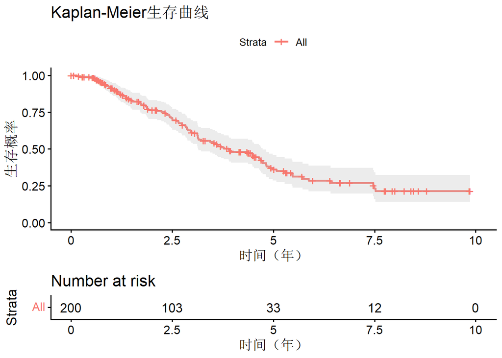

```r
# 绘制生存曲线
survminer::ggsurvplot(km_fit,
                       data = surv_data,
                       conf.int = TRUE,
                       pval = TRUE,
                       risk.table = TRUE,
                       title = "Kaplan-Meier生存曲线",
                       xlab = "时间（年）",
                       ylab = "生存概率")
```

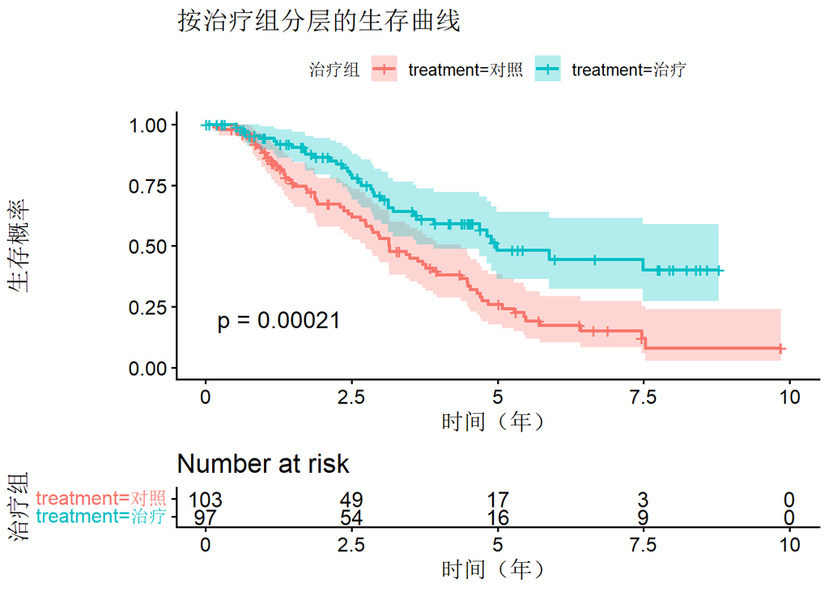

```r
# 按治疗组分组
km_treatment <- survival::survfit(surv_obj ~ treatment, data = surv_data)

# 绘制分组生存曲线
survminer::ggsurvplot(km_treatment,
                       data = surv_data,
                       conf.int = TRUE,
                       pval = TRUE,
                       risk.table = TRUE,
                       legend.title = "治疗组",
                       title = "按治疗组分层的生存曲线",
                       xlab = "时间（年）",
                       ylab = "生存概率")
```

```r
# 中位生存时间
cat("\n========== 中位生存时间 ==========\n")
```

```
##
## ========== 中位生存时间 ==========
```

```r
print(km_fit)
```

```
## Call: survfit(formula = surv_obj ~ 1, data = surv_data)
##
##        n events median 0.95LCL 0.95UCL
## [1,] 200    102   3.89    3.14    4.73
```